# Saxon State Election 2024: Analyses

```r
load("data/processed/data_saxony_main.rdata")
load("data/processed/data_saxony_noexcl.rdata")
load("data/processed/data_saxony_time_main_nooutliers.rdata")
load("data/processed/data_saxony_time_noexcl.rdata")
load("data/processed/data_saxony_ptv_main.rdata")
load("data/processed/data_saxony_ptv_noexcl.rdata")
load("data/processed/data_saxony_ptvties_main.rdata")
load("data/processed/data_saxony_ptvties_noexcl.rdata")
load("data/processed/data_saxony_ptvscore_main.rdata")
load("data/processed/data_saxony_ptvscore_noexcl.rdata")
load("data/processed/data_saxony_vi_main.rdata")
load("data/processed/data_saxony_vi_noexcl.rdata")
load("data/processed/data_saxony_pid_main.rdata")
load("data/processed/data_saxony_pid_noexcl.rdata")
```

# H1: Response Latency

## Model 1

Logged response latency on treatment, logged baseline speed, survey duration and survey date fixed effects (Table C.2).

```r
m_time_full_saxony <- lm(t_list_votes_exp_Page_Submit_log ~ treatment + baseline_speed + duration + lead_time,
  data = data_saxony_time_main_nooutliers
)
summary(m_time_full_saxony)
```

```
Call:
lm(formula = t_list_votes_exp_Page_Submit_log ~ treatment + baseline_speed +
    duration + lead_time, data = data_saxony_time_main_nooutliers)

Residuals:
   Min     1Q Median     3Q    Max
-3.376 -0.330  0.027  0.365  2.372

Coefficients:
                          Estimate Std. Error t value Pr(>|t|)
(Intercept)               2.685232   0.071997   37.30  < 2e-16 ***
treatmentTreatment (500)  0.101576   0.016033    6.34  2.6e-10 ***
baseline_speed            0.750582   0.021567   34.80  < 2e-16 ***
duration                  0.001523   0.000207    7.35  2.3e-13 ***
lead_time3               -0.241606   0.110973   -2.18  0.02951 *
lead_time4                0.155892   0.155895    1.00  0.31736
lead_time5               -0.014872   0.090058   -0.17  0.86884
lead_time6                0.086175   0.071477    1.21  0.22801
lead_time7               -0.442894   0.169635   -2.61  0.00906 **
lead_time8               -0.065158   0.093501   -0.70  0.48591
lead_time9                0.290781   0.076905    3.78  0.00016 ***
lead_time10              -0.422615   0.126984   -3.33  0.00088 ***
lead_time11               0.280562   0.232674    1.21  0.22794
lead_time12               0.311080   0.078692    3.95  7.8e-05 ***
lead_time13               0.250800   0.074095    3.38  0.00072 ***
lead_time14               0.196559   0.068237    2.88  0.00399 **
lead_time15               0.299245   0.075660    3.96  7.7e-05 ***
lead_time16               0.070831   0.072166    0.98  0.32639
lead_time17               0.041784   0.069543    0.60  0.54798
lead_time18              -0.035148   0.065872   -0.53  0.59365
lead_time19               0.119889   0.070114    1.71  0.08734 .
lead_time20               0.115178   0.140006    0.82  0.41074
lead_time21               0.338013   0.097413    3.47  0.00052 ***
lead_time22               0.338257   0.075540    4.48  7.7e-06 ***
lead_time23               0.335887   0.076505    4.39  1.2e-05 ***
lead_time24               0.181136   0.073513    2.46  0.01377 *
lead_time25               0.130634   0.067399    1.94  0.05265 .
lead_time26               0.226193   0.083253    2.72  0.00661 **
lead_time27               0.203831   0.072767    2.80  0.00511 **
lead_time28               0.209890   0.070573    2.97  0.00295 **
lead_time29               0.247861   0.066015    3.75  0.00018 ***
lead_time30               0.231897   0.087585    2.65  0.00813 **
lead_time31               0.224690   0.098450    2.28  0.02251 *
lead_time32               0.139486   0.085958    1.62  0.10471
lead_time33               0.174709   0.091529    1.91  0.05634 .
lead_time34               0.058024   0.078332    0.74  0.45888
lead_time35               0.206451   0.076416    2.70  0.00692 **
lead_time36               0.116574   0.070013    1.67  0.09596 .
lead_time37               0.071331   0.066774    1.07  0.28545
---
Signif. codes:  0 '***' 0.001 '**' 0.01 '*' 0.05 '.' 0.1 ' ' 1

Residual standard error: 0.595 on 5515 degrees of freedom
Multiple R-squared:  0.249, Adjusted R-squared:  0.244
F-statistic:   48 on 38 and 5515 DF,  p-value: <2e-16
```

Predicted latencies in seconds (Rittmann et al. 2025) for an average case: baseline speed and duration at their means, lead time of 20 days.

```r
scenario_means_saxony <- data_saxony_time_main_nooutliers %>%
  summarize(baseline_speed = mean(baseline_speed), duration = mean(duration))
scenario_means_saxony
```

```
# A tibble: 1 × 2
  baseline_speed duration
           <dbl>    <dbl>
1           2.03     21.8
```

```r
set.seed(20240901)
m_time_full_avg_case_sim_saxony <- simloglm(m_time_full_saxony, scenario = list(
  treatment = c("Control", "Treatment (500)"),
  baseline_speed = scenario_means_saxony$baseline_speed,
  duration = scenario_means_saxony$duration,
  lead_time = "20"
))

# First difference of the two scenarios
time_diffs_saxony <- list("T(500) - C" = NULL)
```

## Figure 2: Conditional Median

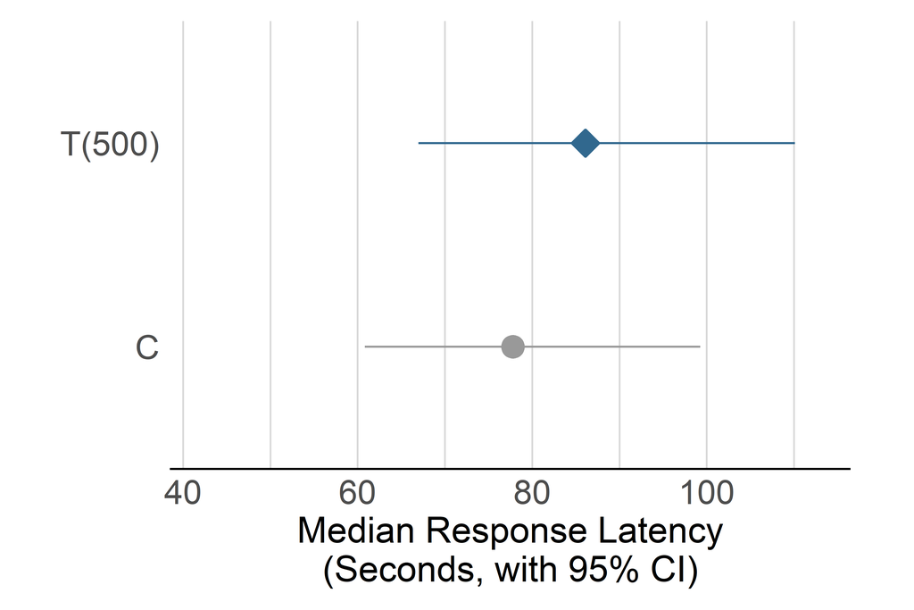

```r
time_median_saxony <- compute_time_effects(m_time_full_avg_case_sim_saxony, "median", time_diffs_saxony) # helper

plot_time_median_saxony <- plot_time_pred( # helper
  create_time_pred_data(time_median_saxony$summary, "Cond. Median", election = "saxony"), # helper
  stat = "Cond. Median", election = "saxony",
  x_limits = x_limits_time_median, x_breaks = x_breaks_time_median
)
plot_time_median_saxony
```

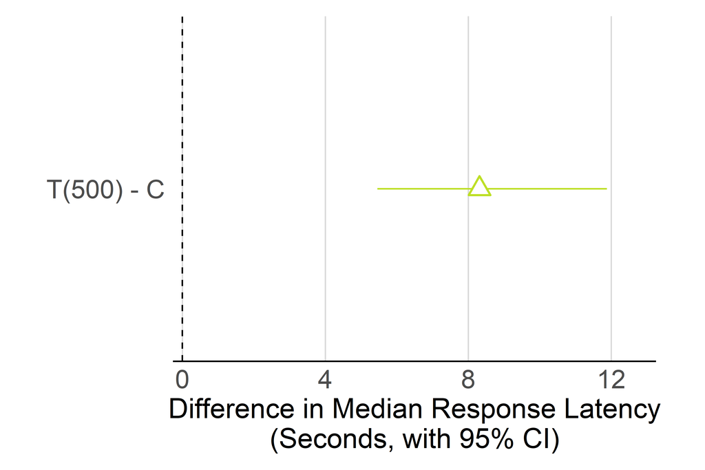

```r
save_figure(plot_time_median_saxony, "figure_2c_h1_median_saxony",
  election = "saxony", # helper
  width = "subfigure", aspect = 1 / 2
)

plot_time_median_fd_saxony <- plot_time_diff( # helper
  create_time_diff_data(time_median_saxony$diff, "FD Median"), # helper
  stat = "FD Median", election = "saxony",
  names_vec = names(time_diffs_saxony),
  x_limits = x_limits_time_fd_median, x_breaks = x_breaks_time_fd_median
)
plot_time_median_fd_saxony
```

```r
save_figure(plot_time_median_fd_saxony, "figure_2d_h1_median_fd_saxony",
  election = "saxony", # helper
  width = "subfigure", aspect = 1 / 2
)
```

```r
create_time_pred_data(time_median_saxony$summary, "Cond. Median", election = "saxony") %>% print_values(digits = 1) # helper
```

```
  Group         Type Estimate Lower Upper
      C Cond. Median     77.8  60.8  99.3
 T(500) Cond. Median     86.1  67.0 110.1
```

```r
create_time_diff_data(time_median_saxony$diff, "FD Median") %>% print_values(digits = 1) # helper
```

```
 Comparison      Type  FD Lower Upper
 T(500) - C FD Median 8.3   5.5  11.9
```

## Figure C.1: Conditional Mean

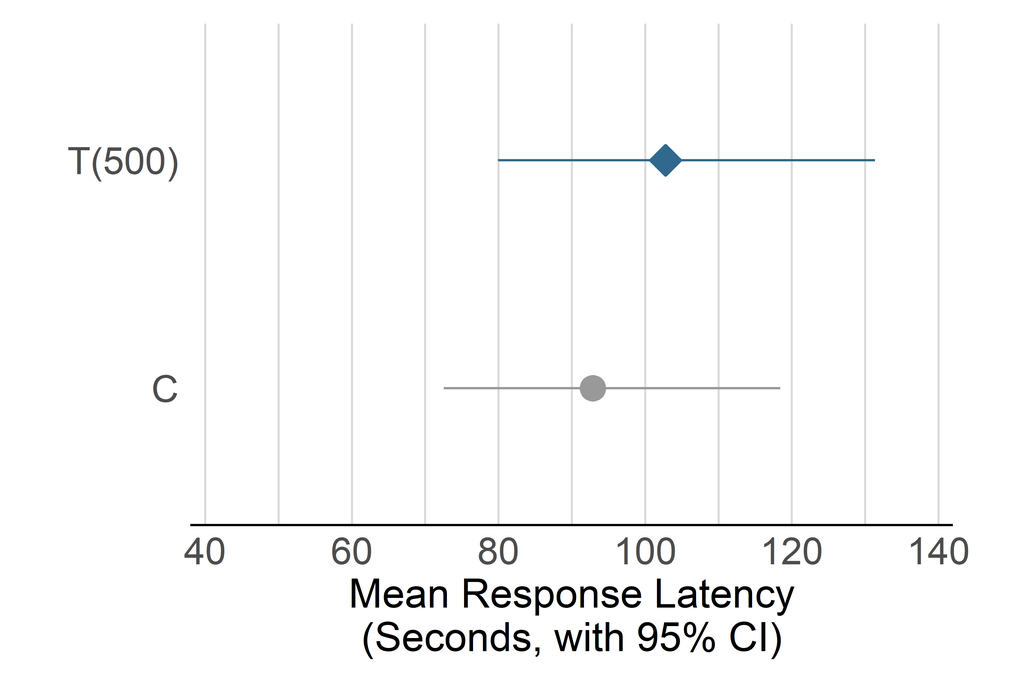

```r
time_mean_saxony <- compute_time_effects(m_time_full_avg_case_sim_saxony, "mean", time_diffs_saxony) # helper

plot_time_mean_saxony <- plot_time_pred( # helper
  create_time_pred_data(time_mean_saxony$summary, "Cond. Mean", election = "saxony"), # helper
  stat = "Cond. Mean", election = "saxony",
  x_limits = x_limits_time_mean, x_breaks = x_breaks_time_mean
)
plot_time_mean_saxony
```

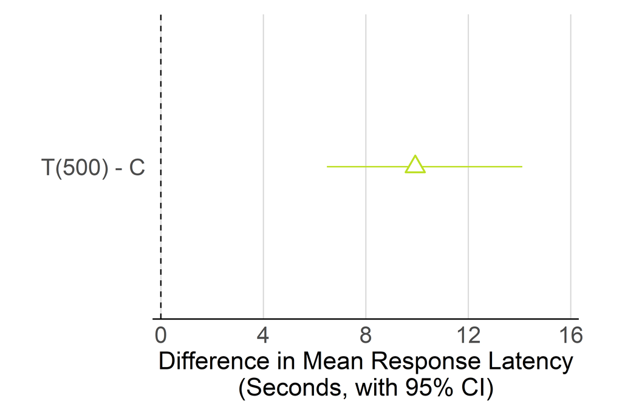

```r
save_figure(plot_time_mean_saxony, "figure_C1c_h1_mean_saxony",
  election = "saxony", # helper
  width = "subfigure", aspect = 1 / 2
)

plot_time_mean_fd_saxony <- plot_time_diff( # helper
  create_time_diff_data(time_mean_saxony$diff, "FD Mean"), # helper
  stat = "FD Mean", election = "saxony",
  names_vec = names(time_diffs_saxony)
)
plot_time_mean_fd_saxony
```

```r
save_figure(plot_time_mean_fd_saxony, "figure_C1d_h1_mean_fd_saxony",
  election = "saxony", # helper
  width = "subfigure", aspect = 1 / 2
)
```

```r
create_time_pred_data(time_mean_saxony$summary, "Cond. Mean", election = "saxony") %>% print_values(digits = 1) # helper
```

```
  Group       Type Estimate Lower Upper
      C Cond. Mean     92.9  72.6 118.4
 T(500) Cond. Mean    102.8  79.9 131.4
```

```r
create_time_diff_data(time_mean_saxony$diff, "FD Mean") %>% print_values(digits = 1) # helper
```

```
 Comparison    Type  FD Lower Upper
 T(500) - C FD Mean 9.9   6.5  14.1
```

# H2: Overall Accuracy

## Model 2a: MAE (Figure 3)

Individual MAE and RMSE (paper section Modeling and appendix section Plots Robustness Checks).

```r
data_saxony_main %>%
  summarize(across(
    c(list_votes_exp_mae, list_votes_exp_rmse),
    list(min = min, mean = mean, sd = sd, max = max)
  )) %>%
  print_values(digits = 2) # helper
```

```
 list_votes_exp_mae_min list_votes_exp_mae_mean list_votes_exp_mae_sd list_votes_exp_mae_max list_votes_exp_rmse_min
                    0.5                    4.77                  3.15                   21.5                     0.6
 list_votes_exp_rmse_mean list_votes_exp_rmse_sd list_votes_exp_rmse_max
                     6.24                   4.51                   35.79
```

```r
m_mae_full_saxony <- lm(list_votes_exp_mae ~ treatment + lead_time, data = data_saxony_main)
summary(m_mae_full_saxony)
```

```
Call:
lm(formula = list_votes_exp_mae ~ treatment + lead_time, data = data_saxony_main)

Residuals:
   Min     1Q Median     3Q    Max
-7.208 -2.089 -0.775  1.297 16.339

Coefficients:
                         Estimate Std. Error t value Pr(>|t|)
(Intercept)                5.6944     0.3024   18.83  < 2e-16 ***
treatmentTreatment (500)  -0.2860     0.0821   -3.48  0.00050 ***
lead_time3                 1.6732     0.5676    2.95  0.00321 **
lead_time4                 0.2682     0.7979    0.34  0.73683
lead_time5                 0.3729     0.4603    0.81  0.41792
lead_time6                -0.4324     0.3649   -1.19  0.23603
lead_time7                 1.6602     0.8683    1.91  0.05594 .
lead_time8                -0.6144     0.4779   -1.29  0.19864
lead_time9                -2.4232     0.3926   -6.17  7.2e-10 ***
lead_time10                2.8272     0.6495    4.35  1.4e-05 ***
lead_time11                1.1223     1.1910    0.94  0.34610
lead_time12               -1.9288     0.4013   -4.81  1.6e-06 ***
lead_time13               -1.6928     0.3781   -4.48  7.7e-06 ***
lead_time14               -0.7315     0.3480   -2.10  0.03561 *
lead_time15               -1.7076     0.3862   -4.42  1.0e-05 ***
lead_time16               -0.4892     0.3679   -1.33  0.18368
lead_time17               -0.2495     0.3547   -0.70  0.48183
lead_time18                0.2149     0.3361    0.64  0.52256
lead_time19               -0.8361     0.3575   -2.34  0.01938 *
lead_time20               -0.1974     0.7158   -0.28  0.78273
lead_time21               -2.1290     0.4972   -4.28  1.9e-05 ***
lead_time22               -1.6503     0.3852   -4.28  1.9e-05 ***
lead_time23               -1.4564     0.3903   -3.73  0.00019 ***
lead_time24               -0.4417     0.3745   -1.18  0.23835
lead_time25               -0.5292     0.3435   -1.54  0.12348
lead_time26               -1.9983     0.4251   -4.70  2.7e-06 ***
lead_time27               -1.2490     0.3707   -3.37  0.00076 ***
lead_time28               -1.4457     0.3598   -4.02  5.9e-05 ***
lead_time29               -1.7290     0.3363   -5.14  2.8e-07 ***
lead_time30               -1.3984     0.4460   -3.14  0.00172 **
lead_time31               -0.6264     0.5027   -1.25  0.21276
lead_time32               -0.6281     0.4391   -1.43  0.15270
lead_time33               -0.8157     0.4676   -1.74  0.08118 .
lead_time34               -0.1739     0.3993   -0.44  0.66316
lead_time35               -0.2449     0.3898   -0.63  0.52991
lead_time36               -0.5411     0.3570   -1.52  0.12964
lead_time37                0.0721     0.3406    0.21  0.83243
---
Signif. codes:  0 '***' 0.001 '**' 0.01 '*' 0.05 '.' 0.1 ' ' 1

Residual standard error: 3.05 on 5525 degrees of freedom
Multiple R-squared:  0.0675,    Adjusted R-squared:  0.0614
F-statistic: 11.1 on 36 and 5525 DF,  p-value: <2e-16
```

```r
mae_saxony <- compute_treatment_effects(m_mae_full_saxony, data_saxony_main) # helper
```

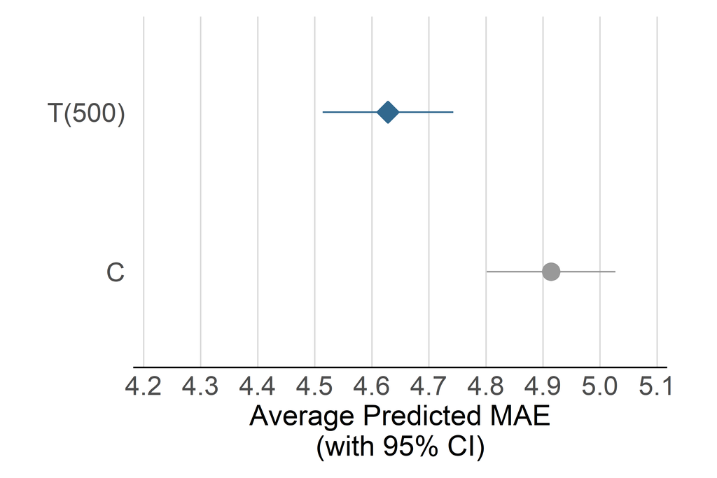

```r
plot_mae_saxony <- plot_accuracy_pred(mae_saxony$pred, "Average Predicted MAE\n(with 95% CI)", # helper
  y_limits = c(4.2, 5.1), y_breaks = seq(4.2, 5.1, by = 0.1),
  election = "saxony"
)
plot_mae_saxony
```

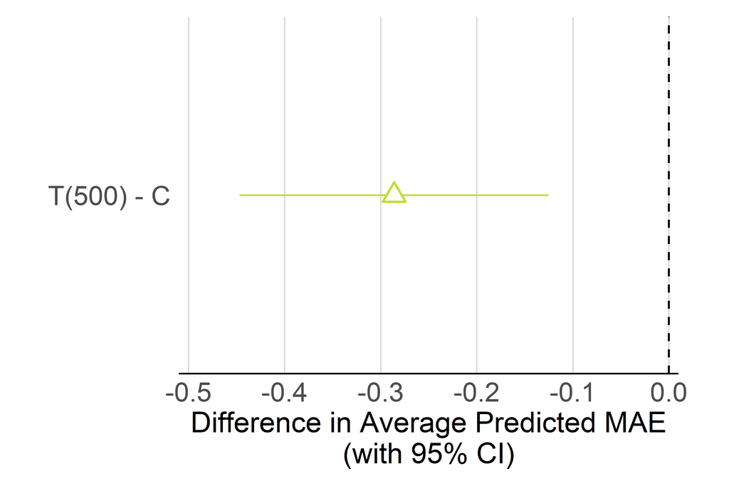

```r
save_figure(plot_mae_saxony, "figure_3c_h2_mae_saxony",
  election = "saxony", # helper
  width = "subfigure", aspect = 1 / 2
)

plot_mae_fd_saxony <- plot_accuracy_diff(mae_saxony$diff, "Difference in Average Predicted MAE\n(with 95% CI)", # helper
  y_limits = c(-0.5, 0), y_breaks = seq(-0.5, 0, by = 0.1),
  election = "saxony"
)
plot_mae_fd_saxony
```

```r
save_figure(plot_mae_fd_saxony, "figure_3d_h2_mae_fd_saxony",
  election = "saxony", # helper
  width = "subfigure", aspect = 1 / 2
)
```

```r
print_values(mae_saxony$pred, c("treatment", est_cols)) # helper
```

```
       treatment estimate conf.low conf.high
         Control     4.91     4.80      5.03
 Treatment (500)     4.63     4.51      4.74
```

```r
print_values(mae_saxony$diff, c("diff", est_cols)) # helper
```

```
       diff estimate conf.low conf.high
 T(500) - C    -0.29    -0.45     -0.13
```

## Model 2b: RMSE (Figure C.2)

```r
m_rmse_full_saxony <- lm(list_votes_exp_rmse ~ treatment + lead_time, data = data_saxony_main)
summary(m_rmse_full_saxony)
```

```
Call:
lm(formula = list_votes_exp_rmse ~ treatment + lead_time, data = data_saxony_main)

Residuals:
   Min     1Q Median     3Q    Max
-10.29  -2.90  -1.21   1.65  28.96

Coefficients:
                         Estimate Std. Error t value Pr(>|t|)
(Intercept)                 7.531      0.434   17.34  < 2e-16 ***
treatmentTreatment (500)   -0.436      0.118   -3.70  0.00021 ***
lead_time3                  2.216      0.815    2.72  0.00655 **
lead_time4                  0.736      1.146    0.64  0.52037
lead_time5                  0.293      0.661    0.44  0.65795
lead_time6                 -0.548      0.524   -1.05  0.29549
lead_time7                  2.346      1.247    1.88  0.05988 .
lead_time8                 -0.851      0.686   -1.24  0.21491
lead_time9                 -3.351      0.564   -5.95  2.9e-09 ***
lead_time10                 4.430      0.932    4.75  2.1e-06 ***
lead_time11                 1.190      1.710    0.70  0.48632
lead_time12                -2.616      0.576   -4.54  5.7e-06 ***
lead_time13                -2.393      0.543   -4.41  1.1e-05 ***
lead_time14                -1.041      0.500   -2.08  0.03725 *
lead_time15                -2.343      0.554   -4.23  2.4e-05 ***
lead_time16                -0.638      0.528   -1.21  0.22723
lead_time17                -0.270      0.509   -0.53  0.59552
lead_time18                 0.220      0.482    0.46  0.64903
lead_time19                -1.186      0.513   -2.31  0.02088 *
lead_time20                -0.135      1.028   -0.13  0.89580
lead_time21                -3.052      0.714   -4.28  1.9e-05 ***
lead_time22                -2.289      0.553   -4.14  3.5e-05 ***
lead_time23                -2.031      0.560   -3.62  0.00029 ***
lead_time24                -0.602      0.538   -1.12  0.26317
lead_time25                -0.753      0.493   -1.53  0.12686
lead_time26                -2.719      0.610   -4.46  8.5e-06 ***
lead_time27                -1.673      0.532   -3.14  0.00167 **
lead_time28                -1.981      0.516   -3.83  0.00013 ***
lead_time29                -2.343      0.483   -4.85  1.3e-06 ***
lead_time30                -2.066      0.640   -3.23  0.00126 **
lead_time31                -0.805      0.722   -1.12  0.26474
lead_time32                -0.770      0.630   -1.22  0.22190
lead_time33                -1.065      0.671   -1.59  0.11274
lead_time34                -0.240      0.573   -0.42  0.67570
lead_time35                -0.358      0.560   -0.64  0.52242
lead_time36                -0.761      0.513   -1.49  0.13758
lead_time37                 0.155      0.489    0.32  0.75163
---
Signif. codes:  0 '***' 0.001 '**' 0.01 '*' 0.05 '.' 0.1 ' ' 1

Residual standard error: 4.38 on 5525 degrees of freedom
Multiple R-squared:  0.0638,    Adjusted R-squared:  0.0577
F-statistic: 10.5 on 36 and 5525 DF,  p-value: <2e-16
```

```r
rmse_saxony <- compute_treatment_effects(m_rmse_full_saxony, data_saxony_main) # helper
```

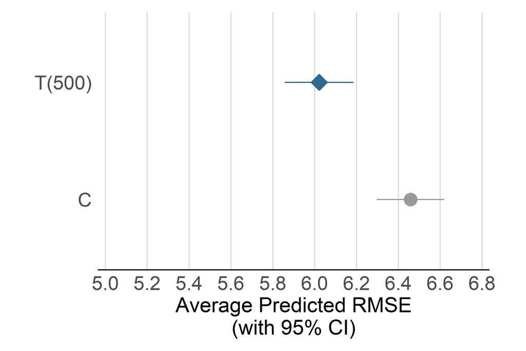

```r
plot_rmse_saxony <- plot_accuracy_pred(rmse_saxony$pred, "Average Predicted RMSE\n(with 95% CI)", # helper
  y_limits = c(5.0, 6.8), y_breaks = seq(5.0, 6.8, by = 0.2),
  election = "saxony"
)
plot_rmse_saxony
```

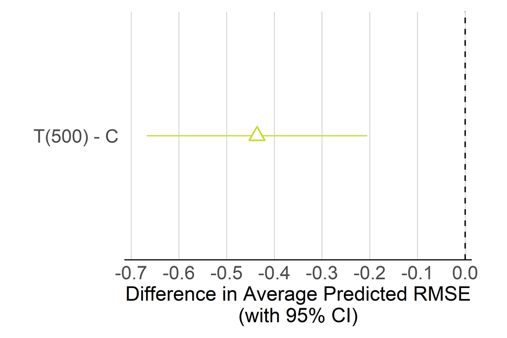

```r
save_figure(plot_rmse_saxony, "figure_C2c_h2_rmse_saxony",
  election = "saxony", # helper
  width = "subfigure", aspect = 1 / 2
)

plot_rmse_fd_saxony <- plot_accuracy_diff(rmse_saxony$diff, "Difference in Average Predicted RMSE\n(with 95% CI)", # helper
  y_limits = c(-0.7, 0), y_breaks = seq(-0.7, 0, by = 0.1),
  election = "saxony"
)
plot_rmse_fd_saxony
```

```r
save_figure(plot_rmse_fd_saxony, "figure_C2d_h2_rmse_fd_saxony",
  election = "saxony", # helper
  width = "subfigure", aspect = 1 / 2
)
```

```r
print_values(rmse_saxony$pred, c("treatment", est_cols)) # helper
```

```
       treatment estimate conf.low conf.high
         Control     6.46     6.30      6.62
 Treatment (500)     6.02     5.86      6.19
```

```r
print_values(rmse_saxony$diff, c("diff", est_cols)) # helper
```

```
       diff estimate conf.low conf.high
 T(500) - C    -0.44    -0.67     -0.21
```

## Heterogeneity by Education (Figure C.9)

MAE on treatment interacted with educational attainment.

```r
data_saxony_educ_main <- data_saxony_main %>%
  filter(!is.na(education_eng), education_eng != "Still in School") %>%
  mutate(education_eng = droplevels(factor(education_eng, levels = c("High", "Medium", "Low"))))

m_mae_educ_saxony <- lm(list_votes_exp_mae ~ treatment * education_eng + lead_time,
  data = data_saxony_educ_main
)
summary(m_mae_educ_saxony)
```

```
Call:
lm(formula = list_votes_exp_mae ~ treatment * education_eng +
    lead_time, data = data_saxony_educ_main)

Residuals:
   Min     1Q Median     3Q    Max
 -7.18  -1.94  -0.71   1.25  16.04

Coefficients:
                                             Estimate Std. Error t value Pr(>|t|)
(Intercept)                                    4.7518     0.2998   15.85  < 2e-16 ***
treatmentTreatment (500)                      -0.4353     0.1112   -3.92  9.1e-05 ***
education_engMedium                            0.8178     0.1163    7.03  2.3e-12 ***
education_engLow                               3.2716     0.2622   12.48  < 2e-16 ***
lead_time3                                     1.4976     0.5427    2.76  0.00581 **
lead_time4                                     0.9513     0.7618    1.25  0.21179
lead_time5                                     0.5287     0.4450    1.19  0.23487
lead_time6                                    -0.2180     0.3522   -0.62  0.53591
lead_time7                                     1.9936     0.8288    2.41  0.01618 *
lead_time8                                    -0.0493     0.4604   -0.11  0.91470
lead_time9                                    -1.8283     0.3807   -4.80  1.6e-06 ***
lead_time10                                    2.6787     0.6208    4.32  1.6e-05 ***
lead_time11                                    2.1716     1.1363    1.91  0.05605 .
lead_time12                                   -1.2163     0.3898   -3.12  0.00182 **
lead_time13                                   -1.2437     0.3658   -3.40  0.00068 ***
lead_time14                                   -0.3588     0.3365   -1.07  0.28637
lead_time15                                   -1.2303     0.3720   -3.31  0.00095 ***
lead_time16                                   -0.2311     0.3551   -0.65  0.51526
lead_time17                                    0.0750     0.3445    0.22  0.82763
lead_time18                                    0.6181     0.3271    1.89  0.05887 .
lead_time19                                   -0.4732     0.3480   -1.36  0.17395
lead_time20                                    0.1933     0.7442    0.26  0.79507
lead_time21                                   -1.4886     0.4795   -3.10  0.00191 **
lead_time22                                   -1.0053     0.3720   -2.70  0.00691 **
lead_time23                                   -0.9564     0.3756   -2.55  0.01091 *
lead_time24                                   -0.1798     0.3640   -0.49  0.62130
lead_time25                                   -0.3371     0.3354   -1.01  0.31485
lead_time26                                   -1.4756     0.4106   -3.59  0.00033 ***
lead_time27                                   -0.8323     0.3587   -2.32  0.02036 *
lead_time28                                   -0.9236     0.3477   -2.66  0.00792 **
lead_time29                                   -1.2320     0.3257   -3.78  0.00016 ***
lead_time30                                   -1.0188     0.4320   -2.36  0.01838 *
lead_time31                                   -0.2292     0.4841   -0.47  0.63586
lead_time32                                   -0.3879     0.4223   -0.92  0.35838
lead_time33                                   -0.5991     0.4483   -1.34  0.18144
lead_time34                                    0.1950     0.3842    0.51  0.61184
lead_time35                                    0.0016     0.3752    0.00  0.99660
lead_time36                                   -0.0771     0.3448   -0.22  0.82307
lead_time37                                    0.3821     0.3285    1.16  0.24490
treatmentTreatment (500):education_engMedium   0.2492     0.1633    1.53  0.12697
treatmentTreatment (500):education_engLow      0.1220     0.3731    0.33  0.74365
---
Signif. codes:  0 '***' 0.001 '**' 0.01 '*' 0.05 '.' 0.1 ' ' 1

Residual standard error: 2.9 on 5349 degrees of freedom
Multiple R-squared:  0.128, Adjusted R-squared:  0.121
F-statistic: 19.5 on 40 and 5349 DF,  p-value: <2e-16
```

```r
data_saxony_educ_main %>% count(education_eng)
```

```
# A tibble: 3 × 2
  education_eng     n
  <fct>         <int>
1 High           2748
2 Medium         2375
3 Low             267
```

```r
mae_educ_saxony <- compute_treatment_effects(m_mae_educ_saxony, data_saxony_educ_main, by = "education_eng") # helper
mae_educ_saxony$pred <- mae_educ_saxony$pred %>%
  mutate(treatment = recode_groups_saxony(treatment)) # helper
mae_educ_saxony$diff <- mae_educ_saxony$diff %>%
  mutate(education_eng = factor(education_eng, levels = c("High", "Medium", "Low")))
```

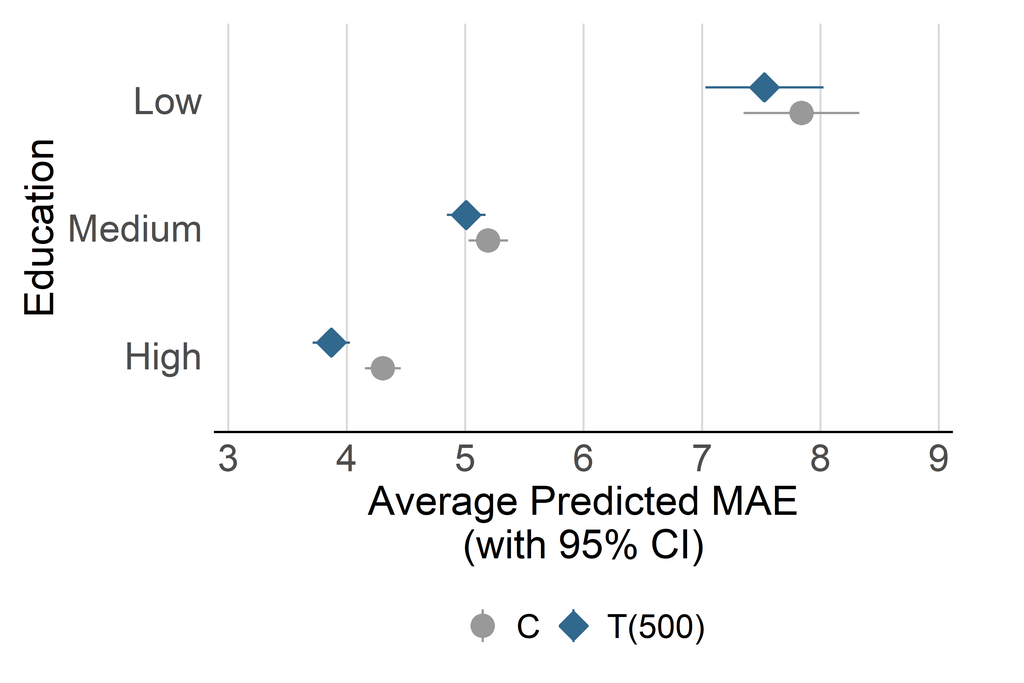

```r
plot_mae_educ_saxony <- plot_by_moderator( # helper
  mae_educ_saxony$pred, "education_eng", "Education", "Average Predicted MAE\n(with 95% CI)",
  election = "saxony", n_breaks = 6
)
plot_mae_educ_saxony
```

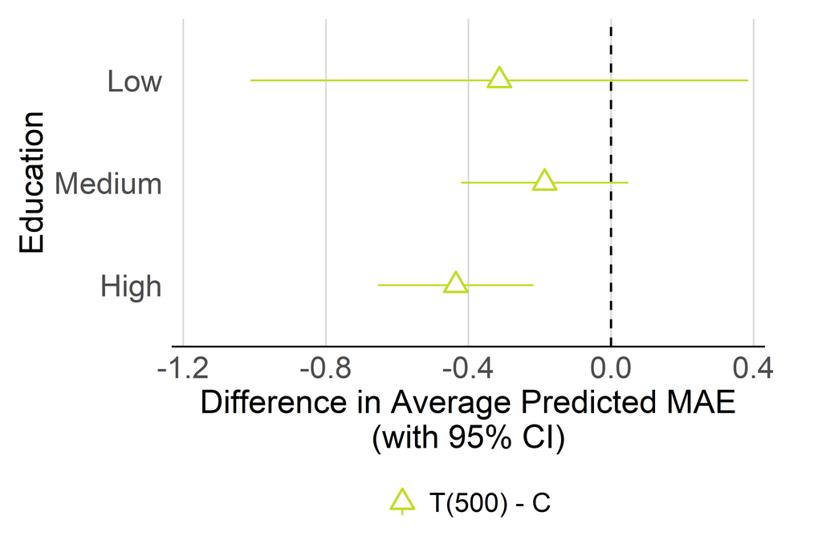

```r
save_figure(plot_mae_educ_saxony, "figure_C9c_h2_mae_educ_saxony",
  election = "saxony", # helper
  width = "subfigure", aspect = 4 / 7
)

plot_mae_educ_fd_saxony <- plot_by_moderator( # helper
  mae_educ_saxony$diff, "education_eng", "Education", "Difference in Average Predicted MAE\n(with 95% CI)",
  election = "saxony", diff = TRUE, y_limits = c(-1.2, 0.4), y_breaks = round(seq(-1.2, 0.4, by = 0.4), 1)
)
plot_mae_educ_fd_saxony
```

```r
save_figure(plot_mae_educ_fd_saxony, "figure_C9d_h2_mae_educ_fd_saxony",
  election = "saxony", # helper
  width = "subfigure", aspect = 4 / 7
)
```

```r
print_values(mae_educ_saxony$diff, c("education_eng", "diff", est_cols)) # helper
```

```
 education_eng       diff estimate conf.low conf.high
          High T(500) - C    -0.44    -0.65     -0.22
        Medium T(500) - C    -0.19    -0.42      0.05
           Low T(500) - C    -0.31    -1.01      0.38
```

## Heterogeneity by Political Interest (Figure C.10)

```r
pol_interest_levels_saxony <- c("sehr stark", "stark", "mittelmäßig", "weniger stark", "überhaupt nicht")

data_saxony_polint_main <- data_saxony_main %>%
  filter(!is.na(pol_interest)) %>%
  mutate(pol_interest = recode_pol_interest(pol_interest, pol_interest_levels_saxony)) # helper

m_mae_polint_saxony <- lm(list_votes_exp_mae ~ treatment * pol_interest + lead_time,
  data = data_saxony_polint_main
)
summary(m_mae_polint_saxony)
```

```
Call:
lm(formula = list_votes_exp_mae ~ treatment * pol_interest +
    lead_time, data = data_saxony_polint_main)

Residuals:
   Min     1Q Median     3Q    Max
-6.562 -1.998 -0.734  1.228 16.052

Coefficients:
                                                Estimate Std. Error t value Pr(>|t|)
(Intercept)                                      4.85564    0.30825   15.75  < 2e-16 ***
treatmentTreatment (500)                        -0.30823    0.14804   -2.08  0.03738 *
pol_interestStrongly                             0.30150    0.13584    2.22  0.02650 *
pol_interestModerately                           1.22034    0.15484    7.88  3.9e-15 ***
pol_interestNot very                             2.19581    0.27288    8.05  1.0e-15 ***
pol_interestNot at all                           3.78580    0.42387    8.93  < 2e-16 ***
lead_time3                                       1.58900    0.55379    2.87  0.00413 **
lead_time4                                       0.12626    0.77810    0.16  0.87110
lead_time5                                       0.20224    0.44890    0.45  0.65235
lead_time6                                      -0.59152    0.35585   -1.66  0.09652 .
lead_time7                                       1.65621    0.84670    1.96  0.05051 .
lead_time8                                      -0.29818    0.46644   -0.64  0.52268
lead_time9                                      -2.04108    0.38341   -5.32  1.1e-07 ***
lead_time10                                      2.86584    0.63323    4.53  6.1e-06 ***
lead_time11                                      1.38634    1.16139    1.19  0.23265
lead_time12                                     -1.51664    0.39206   -3.87  0.00011 ***
lead_time13                                     -1.36153    0.36914   -3.69  0.00023 ***
lead_time14                                     -0.59179    0.33951   -1.74  0.08138 .
lead_time15                                     -1.38861    0.37715   -3.68  0.00023 ***
lead_time16                                     -0.27995    0.35902   -0.78  0.43557
lead_time17                                      0.02884    0.34647    0.08  0.93366
lead_time18                                      0.61034    0.32858    1.86  0.06329 .
lead_time19                                     -0.43483    0.34974   -1.24  0.21381
lead_time20                                     -0.17146    0.69782   -0.25  0.80592
lead_time21                                     -1.77304    0.48514   -3.65  0.00026 ***
lead_time22                                     -1.29254    0.37616   -3.44  0.00059 ***
lead_time23                                     -1.19911    0.38082   -3.15  0.00165 **
lead_time24                                     -0.17178    0.36544   -0.47  0.63832
lead_time25                                     -0.16522    0.33592   -0.49  0.62285
lead_time26                                     -1.51458    0.41581   -3.64  0.00027 ***
lead_time27                                     -0.88837    0.36220   -2.45  0.01421 *
lead_time28                                     -0.99789    0.35182   -2.84  0.00458 **
lead_time29                                     -1.26389    0.32928   -3.84  0.00013 ***
lead_time30                                     -1.03682    0.43545   -2.38  0.01730 *
lead_time31                                     -0.39466    0.49022   -0.81  0.42081
lead_time32                                     -0.38474    0.42818   -0.90  0.36893
lead_time33                                     -0.54124    0.45618   -1.19  0.23549
lead_time34                                     -0.29631    0.38944   -0.76  0.44677
lead_time35                                     -0.20543    0.37999   -0.54  0.58880
lead_time36                                     -0.44380    0.34808   -1.28  0.20236
lead_time37                                     -0.00545    0.33231   -0.02  0.98692
treatmentTreatment (500):pol_interestStrongly    0.03859    0.19617    0.20  0.84405
treatmentTreatment (500):pol_interestModerately  0.03166    0.21811    0.15  0.88459
treatmentTreatment (500):pol_interestNot very   -0.57488    0.37300   -1.54  0.12332
treatmentTreatment (500):pol_interestNot at all -0.30150    0.59968   -0.50  0.61515
---
Signif. codes:  0 '***' 0.001 '**' 0.01 '*' 0.05 '.' 0.1 ' ' 1

Residual standard error: 2.97 on 5514 degrees of freedom
Multiple R-squared:  0.115, Adjusted R-squared:  0.108
F-statistic: 16.3 on 44 and 5514 DF,  p-value: <2e-16
```

```r
data_saxony_polint_main %>% count(pol_interest)
```

```
# A tibble: 5 × 2
  pol_interest      n
  <fct>         <int>
1 Very strongly  1624
2 Strongly       2141
3 Moderately     1383
4 Not very        306
5 Not at all      105
```

```r
mae_polint_saxony <- compute_treatment_effects(m_mae_polint_saxony, data_saxony_polint_main, by = "pol_interest") # helper
mae_polint_saxony$pred <- mae_polint_saxony$pred %>%
  mutate(treatment = recode_groups_saxony(treatment)) # helper
mae_polint_saxony$diff <- mae_polint_saxony$diff %>%
  mutate(pol_interest = factor(pol_interest, levels = levels(data_saxony_polint_main$pol_interest)))
```

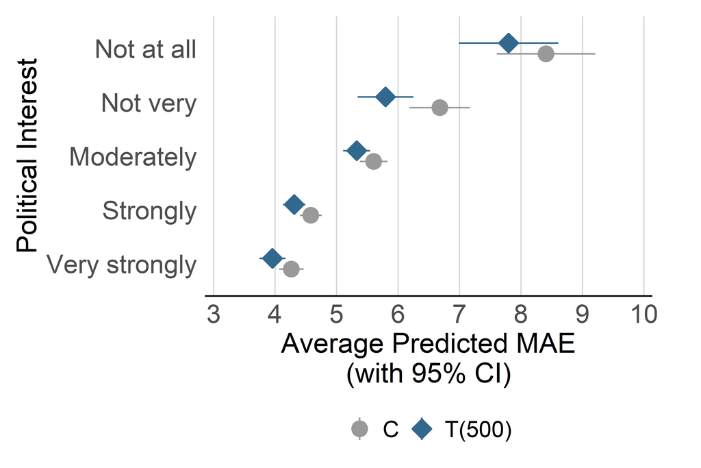

```r
plot_mae_polint_saxony <- plot_by_moderator( # helper
  mae_polint_saxony$pred, "pol_interest", "Political Interest", "Average Predicted MAE\n(with 95% CI)",
  election = "saxony"
)
plot_mae_polint_saxony
```

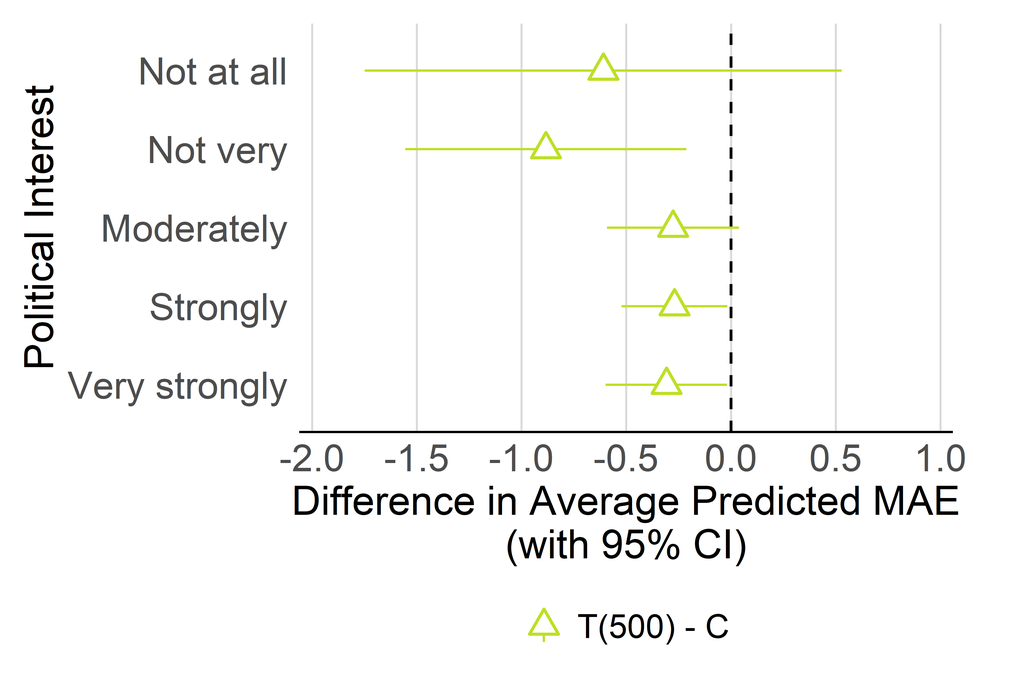

```r
save_figure(plot_mae_polint_saxony, "figure_C10c_h2_mae_polint_saxony",
  election = "saxony", # helper
  width = "subfigure", aspect = 5 / 8
)

plot_mae_polint_fd_saxony <- plot_by_moderator( # helper
  mae_polint_saxony$diff, "pol_interest", "Political Interest", "Difference in Average Predicted MAE\n(with 95% CI)",
  election = "saxony", diff = TRUE
)
plot_mae_polint_fd_saxony
```

```r
save_figure(plot_mae_polint_fd_saxony, "figure_C10d_h2_mae_polint_fd_saxony",
  election = "saxony", # helper
  width = "subfigure", aspect = 5 / 8
)
```

# H3: Wishful Thinking

## Wishful Thinking by Party (Figures 4 and B.7)

One model per party: forecast error on whether the party is the respondent’s preferred party (highest PTV).

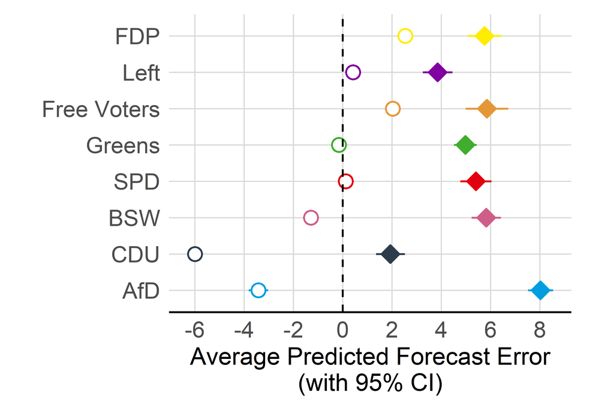

```r
wt_byparty_ptv_saxony <- fit_wt_by_party(data_saxony_ptv_main, "preferred_party_ptv_dummy", # helper
  parties_8_saxony,
  election = "saxony"
)

plot_wt_byparty_saxony <- plot_wt_by_party_pred(wt_byparty_ptv_saxony$pred, election = "saxony") # helper
plot_wt_byparty_saxony
```

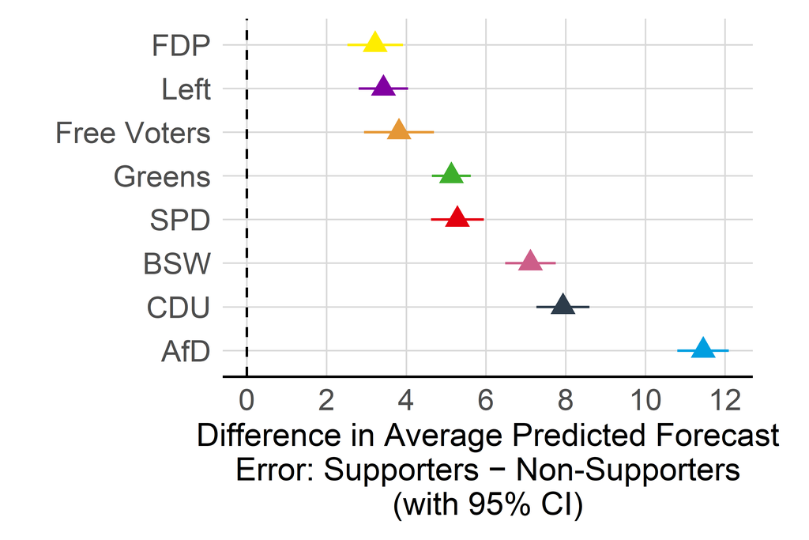

```r
save_figure(plot_wt_byparty_saxony, "figure_B7c_h3_wt_byparty_saxony",
  election = "saxony", # helper
  width = "subfigure", aspect = 6 / 8
)

plot_wt_byparty_fd_saxony <- plot_wt_by_party_diff(wt_byparty_ptv_saxony$diff, election = "saxony") # helper
plot_wt_byparty_fd_saxony
```

```r
save_figure(plot_wt_byparty_fd_saxony, "figure_4b_h3_wt_byparty_fd_saxony",
  election = "saxony", # helper
  width = "subfigure", aspect = 6 / 8
)
```

```r
print_values(wt_byparty_ptv_saxony$pred, c("party", "preferred_party_dummy", est_cols)) # helper
```

```
       party preferred_party_dummy estimate conf.low conf.high
         AfD                    no    -3.42    -3.81     -3.03
         AfD                   yes     8.03     7.52      8.54
         BSW                    no    -1.29    -1.50     -1.08
         BSW                   yes     5.83     5.23      6.42
         CDU                    no    -5.99    -6.31     -5.68
         CDU                   yes     1.94     1.35      2.52
         FDP                    no     2.54     2.42      2.65
         FDP                   yes     5.76     5.07      6.44
      Greens                    no    -0.16    -0.32      0.01
      Greens                   yes     4.98     4.52      5.44
        Left                    no     0.42     0.28      0.57
        Left                   yes     3.85     3.25      4.46
         SPD                    no     0.12    -0.06      0.30
         SPD                   yes     5.41     4.77      6.04
 Free Voters                    no     2.03     1.89      2.18
 Free Voters                   yes     5.85     4.99      6.72
```

```r
print_values(wt_byparty_ptv_saxony$diff, c("party", "diff", est_cols), digits = 1) # helper
```

```
       party     diff estimate conf.low conf.high
         AfD yes - no     11.4     10.8      12.1
         BSW yes - no      7.1      6.5       7.7
         CDU yes - no      7.9      7.3       8.6
         FDP yes - no      3.2      2.5       3.9
      Greens yes - no      5.1      4.6       5.6
        Left yes - no      3.4      2.8       4.1
         SPD yes - no      5.3      4.6       5.9
 Free Voters yes - no      3.8      2.9       4.7
```

## Model 3a: Preferred Party by PTV Dummy (Figure 5)

Forecast error on treatment interacted with the preferred-party dummy, with survey date and party fixed effects. Standard errors are clustered by respondent.

```r
m_pref_ptv_saxony <- lm(list_votes_exp_diff ~ treatment * preferred_party_ptv_dummy + lead_time + party,
  data = data_saxony_ptv_main
)
lmtest::coeftest(m_pref_ptv_saxony, vcov = sandwich::vcovCL(m_pref_ptv_saxony, cluster = ~ResponseId))
```

```
t test of coefficients:

                                                   Estimate Std. Error t value Pr(>|t|)
(Intercept)                                        -2.02418    0.18460  -10.97  < 2e-16 ***
treatmentTreatment (500)                            0.18863    0.04749    3.97  7.1e-05 ***
preferred_party_ptv_dummy                           8.51335    0.29562   28.80  < 2e-16 ***
lead_time3                                         -0.04119    0.09876   -0.42   0.6766
lead_time4                                         -0.11540    0.11492   -1.00   0.3153
lead_time5                                         -0.02292    0.07280   -0.31   0.7529
lead_time6                                         -0.03030    0.05634   -0.54   0.5908
lead_time7                                          0.16292    0.08639    1.89   0.0593 .
lead_time8                                         -0.12061    0.10374   -1.16   0.2450
lead_time9                                         -0.10417    0.05688   -1.83   0.0670 .
lead_time10                                         0.16735    0.07501    2.23   0.0257 *
lead_time11                                         0.17445    0.41742    0.42   0.6760
lead_time12                                        -0.14218    0.07070   -2.01   0.0443 *
lead_time13                                        -0.07959    0.05480   -1.45   0.1464
lead_time14                                        -0.07730    0.05673   -1.36   0.1730
lead_time15                                        -0.10539    0.05872   -1.79   0.0727 .
lead_time16                                        -0.12781    0.06198   -2.06   0.0392 *
lead_time17                                        -0.09641    0.06073   -1.59   0.1124
lead_time18                                        -0.07903    0.05770   -1.37   0.1708
lead_time19                                        -0.05002    0.05480   -0.91   0.3613
lead_time20                                        -0.06275    0.09484   -0.66   0.5082
lead_time21                                        -0.04186    0.06960   -0.60   0.5476
lead_time22                                        -0.12100    0.06088   -1.99   0.0469 *
lead_time23                                        -0.09528    0.06266   -1.52   0.1284
lead_time24                                        -0.06038    0.06093   -0.99   0.3217
lead_time25                                        -0.14818    0.05294   -2.80   0.0051 **
lead_time26                                        -0.17804    0.06724   -2.65   0.0081 **
lead_time27                                        -0.06690    0.06013   -1.11   0.2659
lead_time28                                        -0.15917    0.05750   -2.77   0.0056 **
lead_time29                                        -0.12757    0.05485   -2.33   0.0200 *
lead_time30                                        -0.18649    0.07594   -2.46   0.0141 *
lead_time31                                        -0.00475    0.07307   -0.07   0.9481
lead_time32                                        -0.06823    0.06800   -1.00   0.3157
lead_time33                                         0.00436    0.06779    0.06   0.9487
lead_time34                                        -0.06117    0.06478   -0.94   0.3451
lead_time35                                        -0.14923    0.06743   -2.21   0.0269 *
lead_time36                                        -0.04256    0.06498   -0.66   0.5125
lead_time37                                         0.00663    0.05160    0.13   0.8978
partyBSW                                            0.66648    0.20447    3.26   0.0011 **
partyCDU                                           -3.91848    0.23561  -16.63  < 2e-16 ***
partyFDP                                            4.42767    0.20069   22.06  < 2e-16 ***
partyFree Voters                                    3.94133    0.19882   19.82  < 2e-16 ***
partyGreens                                         1.58046    0.20931    7.55  4.4e-14 ***
partyLeft                                           2.20056    0.20280   10.85  < 2e-16 ***
partySPD                                            1.95316    0.22306    8.76  < 2e-16 ***
treatmentTreatment (500):preferred_party_ptv_dummy -1.69093    0.36970   -4.57  4.8e-06 ***
---
Signif. codes:  0 '***' 0.001 '**' 0.01 '*' 0.05 '.' 0.1 ' ' 1
```

```r
count_model_n(m_pref_ptv_saxony, data_saxony_ptv_main) # helper
```

```
# A tibble: 1 × 2
  respondents observations
        <int>        <int>
1        4665        37187
```

```r
ptv_saxony <- compute_treatment_effects(m_pref_ptv_saxony, data_saxony_ptv_main, # helper
  by = "preferred_party_ptv_dummy", vcov = ~ResponseId
)
```

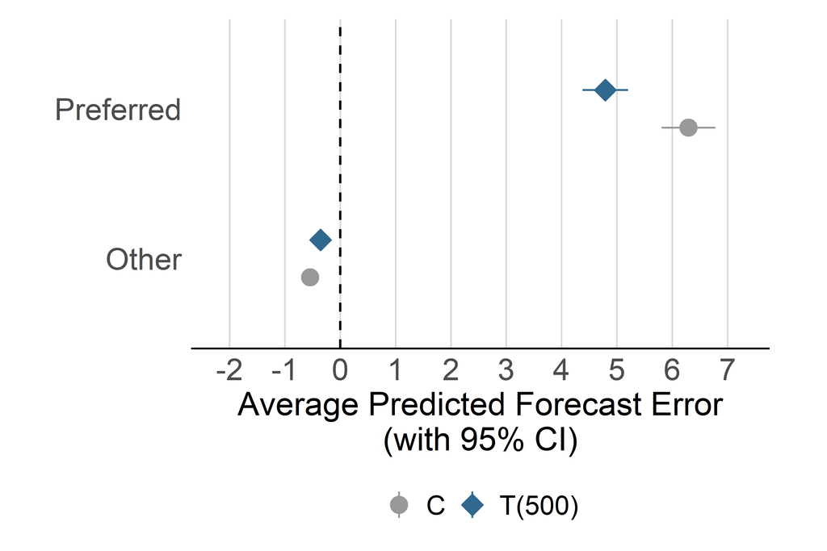

```r
plot_pref_ptv_saxony <- plot_wishful_thinking_pred(ptv_saxony$pred, "preferred_party_ptv_dummy", # helper
  election = "saxony"
)
plot_pref_ptv_saxony
```

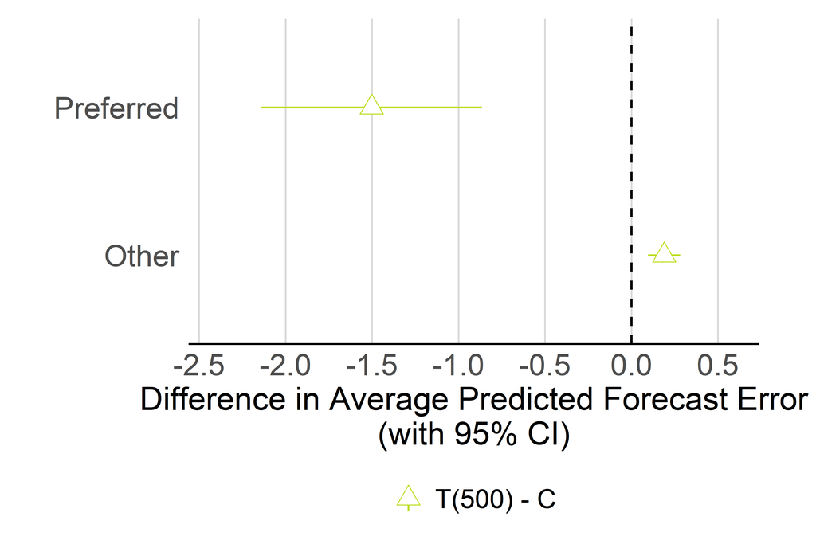

```r
save_figure(plot_pref_ptv_saxony, "figure_5c_h3_ptv_saxony",
  election = "saxony", # helper
  width = "subfigure", aspect = 1 / 2
)

plot_pref_ptv_fd_saxony <- plot_wishful_thinking_diff(ptv_saxony$diff, "preferred_party_ptv_dummy", # helper
  election = "saxony",
  y_limits = c(-2.5, 0.5),
  y_breaks = seq(-2.5, 0.5, by = 0.5)
)
plot_pref_ptv_fd_saxony
```

```r
save_figure(plot_pref_ptv_fd_saxony, "figure_5d_h3_ptv_fd_saxony",
  election = "saxony", # helper
  width = "subfigure", aspect = 1 / 2
)
```

```r
print_values(ptv_saxony$pred, c("treatment", "preferred_party_ptv_dummy", est_cols)) # helper
```

```
       treatment preferred_party_ptv_dummy estimate conf.low conf.high
         Control                         0    -0.54    -0.61     -0.47
         Control                         1     6.29     5.81      6.78
 Treatment (500)                         0    -0.36    -0.42     -0.30
 Treatment (500)                         1     4.79     4.38      5.20
```

```r
print_values(ptv_saxony$diff, c("diff", "preferred_party_ptv_dummy", est_cols)) # helper
```

```
       diff preferred_party_ptv_dummy estimate conf.low conf.high
 T(500) - C                         0     0.19     0.10      0.28
 T(500) - C                         1    -1.50    -2.14     -0.86
```

## Model 3b: PTV Dummy Including Ties (Figure C.3)

All parties sharing the highest PTV count as preferred.

```r
m_pref_ptv_ties_saxony <- lm(list_votes_exp_diff ~ treatment * preferred_party_ptv_dummy_ties + lead_time + party,
  data = data_saxony_ptvties_main
)
lmtest::coeftest(m_pref_ptv_ties_saxony, vcov = sandwich::vcovCL(m_pref_ptv_ties_saxony, cluster = ~ResponseId))
```

```
t test of coefficients:

                                                        Estimate Std. Error t value Pr(>|t|)
(Intercept)                                             -1.94402    0.18253  -10.65  < 2e-16 ***
treatmentTreatment (500)                                 0.19147    0.04719    4.06  5.0e-05 ***
preferred_party_ptv_dummy_ties                           6.83600    0.24306   28.13  < 2e-16 ***
lead_time3                                              -0.17440    0.18409   -0.95    0.343
lead_time4                                              -0.14842    0.18353   -0.81    0.419
lead_time5                                              -0.14257    0.15720   -0.91    0.364
lead_time6                                              -0.06399    0.09301   -0.69    0.491
lead_time7                                               0.11131    0.17735    0.63    0.530
lead_time8                                               0.01296    0.12240    0.11    0.916
lead_time9                                              -0.02413    0.08862   -0.27    0.785
lead_time10                                             -0.25256    0.27801   -0.91    0.364
lead_time11                                              0.05745    0.27738    0.21    0.836
lead_time12                                             -0.06112    0.09941   -0.61    0.539
lead_time13                                              0.01491    0.08629    0.17    0.863
lead_time14                                              0.00405    0.08796    0.05    0.963
lead_time15                                              0.01334    0.08576    0.16    0.876
lead_time16                                             -0.13690    0.11386   -1.20    0.229
lead_time17                                             -0.07789    0.09956   -0.78    0.434
lead_time18                                             -0.10432    0.08979   -1.16    0.245
lead_time19                                             -0.05356    0.09029   -0.59    0.553
lead_time20                                              0.03947    0.11847    0.33    0.739
lead_time21                                              0.09134    0.09546    0.96    0.339
lead_time22                                             -0.02523    0.08753   -0.29    0.773
lead_time23                                              0.05155    0.09366    0.55    0.582
lead_time24                                              0.00198    0.09109    0.02    0.983
lead_time25                                             -0.06219    0.08532   -0.73    0.466
lead_time26                                              0.00202    0.09027    0.02    0.982
lead_time27                                              0.08917    0.08501    1.05    0.294
lead_time28                                             -0.13192    0.09531   -1.38    0.166
lead_time29                                             -0.04194    0.08148   -0.51    0.607
lead_time30                                             -0.02077    0.09808   -0.21    0.832
lead_time31                                              0.15207    0.10416    1.46    0.144
lead_time32                                              0.02081    0.09463    0.22    0.826
lead_time33                                              0.09770    0.09531    1.03    0.305
lead_time34                                             -0.02469    0.11276   -0.22    0.827
lead_time35                                             -0.15387    0.11869   -1.30    0.195
lead_time36                                             -0.06143    0.09909   -0.62    0.535
lead_time37                                             -0.10515    0.09893   -1.06    0.288
partyBSW                                                 0.38154    0.18998    2.01    0.045 *
partyCDU                                                -4.04516    0.22221  -18.20  < 2e-16 ***
partyFDP                                                 4.21397    0.18630   22.62  < 2e-16 ***
partyFree Voters                                         3.65968    0.18306   19.99  < 2e-16 ***
partyGreens                                              1.46458    0.19644    7.46  9.1e-14 ***
partyLeft                                                2.13438    0.19379   11.01  < 2e-16 ***
partySPD                                                 1.82997    0.21015    8.71  < 2e-16 ***
treatmentTreatment (500):preferred_party_ptv_dummy_ties -1.25024    0.31274   -4.00  6.4e-05 ***
---
Signif. codes:  0 '***' 0.001 '**' 0.01 '*' 0.05 '.' 0.1 ' ' 1
```

```r
count_model_n(m_pref_ptv_ties_saxony, data_saxony_ptvties_main) # helper
```

```
# A tibble: 1 × 2
  respondents observations
        <int>        <int>
1        5554        44432
```

```r
ptv_ties_saxony <- compute_treatment_effects(m_pref_ptv_ties_saxony, data_saxony_ptvties_main, # helper
  by = "preferred_party_ptv_dummy_ties", vcov = ~ResponseId
)
```

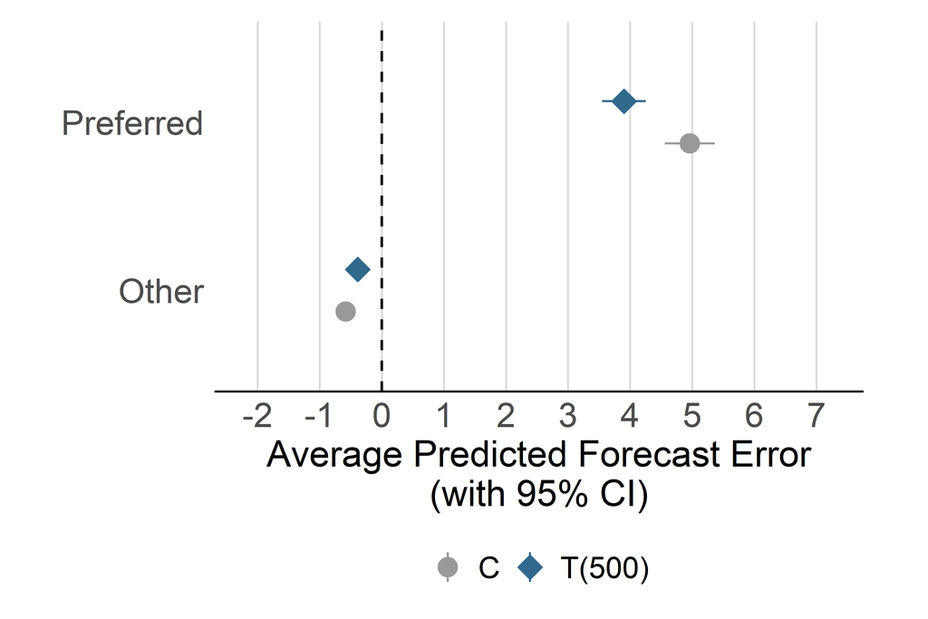

```r
plot_pref_ptv_ties_saxony <- plot_wishful_thinking_pred(ptv_ties_saxony$pred, "preferred_party_ptv_dummy_ties", # helper
  election = "saxony"
)
plot_pref_ptv_ties_saxony
```

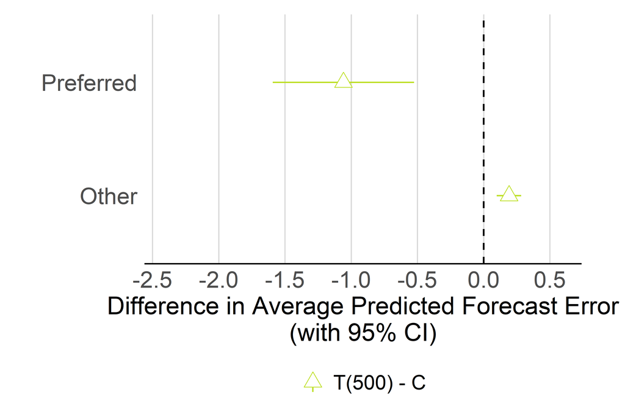

```r
save_figure(plot_pref_ptv_ties_saxony, "figure_C3c_h3_ptv_ties_saxony",
  election = "saxony", # helper
  width = "subfigure", aspect = 1 / 2
)

plot_pref_ptv_ties_fd_saxony <- plot_wishful_thinking_diff(ptv_ties_saxony$diff, "preferred_party_ptv_dummy_ties", # helper
  election = "saxony",
  y_limits = c(-2.5, 0.5),
  y_breaks = seq(-2.5, 0.5, by = 0.5)
)
plot_pref_ptv_ties_fd_saxony
```

```r
save_figure(plot_pref_ptv_ties_fd_saxony, "figure_C3d_h3_ptv_ties_fd_saxony",
  election = "saxony", # helper
  width = "subfigure", aspect = 1 / 2
)
```

```r
print_values(ptv_ties_saxony$diff, c("diff", "preferred_party_ptv_dummy_ties", est_cols)) # helper
```

```
       diff preferred_party_ptv_dummy_ties estimate conf.low conf.high
 T(500) - C                              0     0.19     0.10      0.28
 T(500) - C                              1    -1.06    -1.59     -0.52
```

## Model 3c: Vote Intention (Figure C.4)

```r
m_pref_vi_saxony <- lm(list_votes_exp_diff ~ treatment * preferred_party_vi_dummy + lead_time + party,
  data = data_saxony_vi_main
)
lmtest::coeftest(m_pref_vi_saxony, vcov = sandwich::vcovCL(m_pref_vi_saxony, cluster = ~ResponseId))
```

```
t test of coefficients:

                                                  Estimate Std. Error t value Pr(>|t|)
(Intercept)                                       -2.35792    0.17742  -13.29  < 2e-16 ***
treatmentTreatment (500)                           0.19150    0.04509    4.25  2.2e-05 ***
preferred_party_vi_dummy                           8.75231    0.28413   30.80  < 2e-16 ***
lead_time3                                        -0.02278    0.10970   -0.21    0.836
lead_time4                                        -0.06905    0.10525   -0.66    0.512
lead_time5                                        -0.01370    0.07046   -0.19    0.846
lead_time6                                         0.00161    0.05355    0.03    0.976
lead_time7                                         0.09471    0.11646    0.81    0.416
lead_time8                                        -0.14362    0.10295   -1.40    0.163
lead_time9                                        -0.07573    0.05374   -1.41    0.159
lead_time10                                        0.14731    0.07570    1.95    0.052 .
lead_time11                                       -0.17425    0.26622   -0.65    0.513
lead_time12                                       -0.13653    0.06762   -2.02    0.043 *
lead_time13                                       -0.06677    0.05239   -1.27    0.202
lead_time14                                       -0.02648    0.05108   -0.52    0.604
lead_time15                                       -0.08297    0.05576   -1.49    0.137
lead_time16                                       -0.07076    0.05745   -1.23    0.218
lead_time17                                       -0.05083    0.05624   -0.90    0.366
lead_time18                                       -0.05907    0.05409   -1.09    0.275
lead_time19                                       -0.04275    0.05267   -0.81    0.417
lead_time20                                       -0.03988    0.08624   -0.46    0.644
lead_time21                                       -0.02855    0.06534   -0.44    0.662
lead_time22                                       -0.08095    0.05671   -1.43    0.153
lead_time23                                       -0.05042    0.05919   -0.85    0.394
lead_time24                                       -0.05332    0.05718   -0.93    0.351
lead_time25                                       -0.12446    0.05182   -2.40    0.016 *
lead_time26                                       -0.15457    0.06470   -2.39    0.017 *
lead_time27                                       -0.04124    0.05766   -0.72    0.475
lead_time28                                       -0.07690    0.05135   -1.50    0.134
lead_time29                                       -0.10081    0.04939   -2.04    0.041 *
lead_time30                                       -0.13134    0.07337   -1.79    0.073 .
lead_time31                                       -0.05347    0.07356   -0.73    0.467
lead_time32                                       -0.04092    0.06223   -0.66    0.511
lead_time33                                        0.04087    0.06250    0.65    0.513
lead_time34                                       -0.00907    0.06129   -0.15    0.882
lead_time35                                       -0.11957    0.07506   -1.59    0.111
lead_time36                                       -0.03771    0.05877   -0.64    0.521
lead_time37                                       -0.00252    0.05237   -0.05    0.962
partyBSW                                           0.88209    0.19212    4.59  4.4e-06 ***
partyCDU                                          -3.71200    0.22562  -16.45  < 2e-16 ***
partyFDP                                           4.80404    0.19296   24.90  < 2e-16 ***
partyFree Voters                                   4.28953    0.19190   22.35  < 2e-16 ***
partyGreens                                        1.98674    0.20124    9.87  < 2e-16 ***
partyLeft                                          2.71749    0.20145   13.49  < 2e-16 ***
partySPD                                           2.27707    0.21618   10.53  < 2e-16 ***
treatmentTreatment (500):preferred_party_vi_dummy -1.75100    0.35547   -4.93  8.4e-07 ***
---
Signif. codes:  0 '***' 0.001 '**' 0.01 '*' 0.05 '.' 0.1 ' ' 1
```

```r
count_model_n(m_pref_vi_saxony, data_saxony_vi_main) # helper
```

```
# A tibble: 1 × 2
  respondents observations
        <int>        <int>
1        5269        42152
```

```r
vi_saxony <- compute_treatment_effects(m_pref_vi_saxony, data_saxony_vi_main, # helper
  by = "preferred_party_vi_dummy", vcov = ~ResponseId
)
```

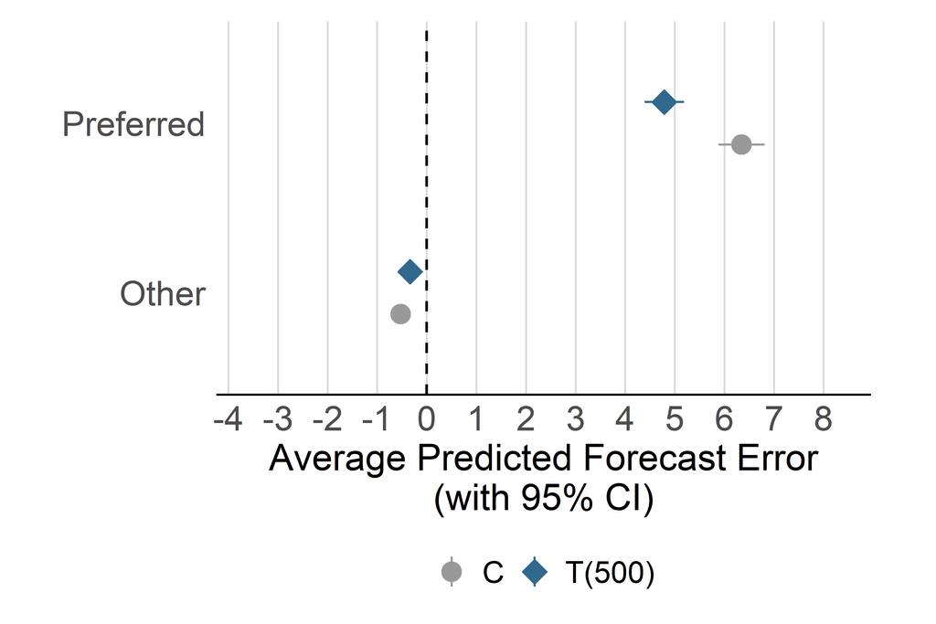

```r
plot_pref_vi_saxony <- plot_wishful_thinking_pred(vi_saxony$pred, "preferred_party_vi_dummy", # helper
  election = "saxony",
  y_limits = c(-4, 8), y_breaks = seq(-4, 8, by = 1)
)
plot_pref_vi_saxony
```

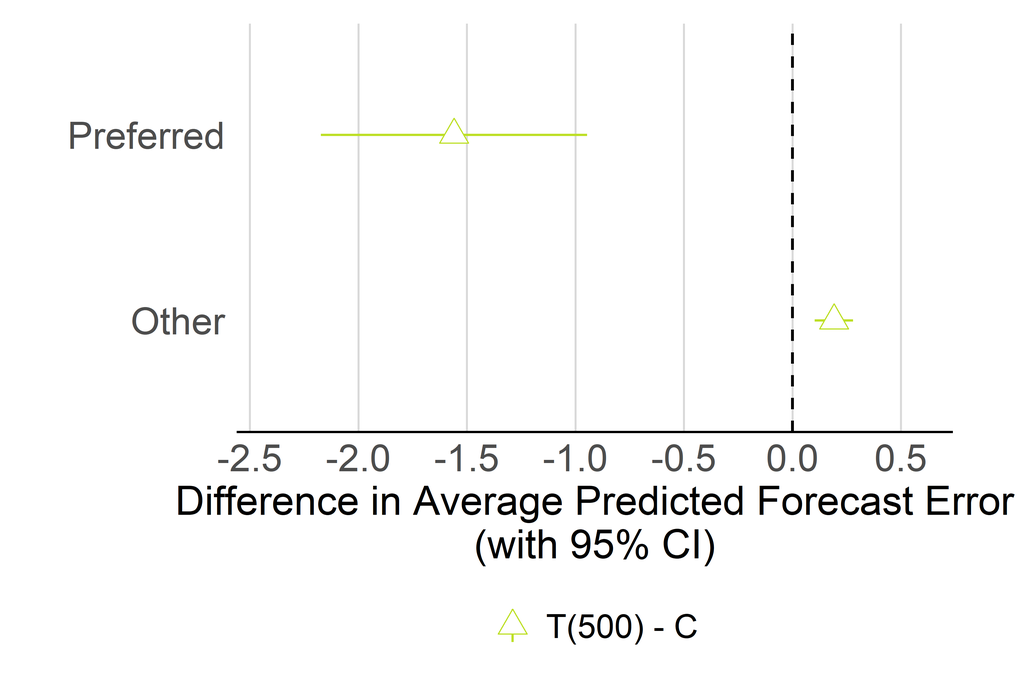

```r
save_figure(plot_pref_vi_saxony, "figure_C4c_h3_vi_saxony",
  election = "saxony", # helper
  width = "subfigure", aspect = 1 / 2
)

plot_pref_vi_fd_saxony <- plot_wishful_thinking_diff(vi_saxony$diff, "preferred_party_vi_dummy", # helper
  election = "saxony",
  y_limits = c(-2.5, 0.5),
  y_breaks = seq(-2.5, 0.5, by = 0.5)
)
plot_pref_vi_fd_saxony
```

```r
save_figure(plot_pref_vi_fd_saxony, "figure_C4d_h3_vi_fd_saxony",
  election = "saxony", # helper
  width = "subfigure", aspect = 1 / 2
)
```

```r
print_values(vi_saxony$diff, c("diff", "preferred_party_vi_dummy", est_cols)) # helper
```

```
       diff preferred_party_vi_dummy estimate conf.low conf.high
 T(500) - C                        0     0.19     0.10      0.28
 T(500) - C                        1    -1.56    -2.17     -0.95
```

## Model 3d: Party Identification (Figure C.5)

```r
m_pref_pid_saxony <- lm(list_votes_exp_diff ~ treatment * preferred_party_pid_dummy + lead_time + party,
  data = data_saxony_pid_main
)
lmtest::coeftest(m_pref_pid_saxony, vcov = sandwich::vcovCL(m_pref_pid_saxony, cluster = ~ResponseId))
```

```
t test of coefficients:

                                                    Estimate Std. Error t value Pr(>|t|)
(Intercept)                                        -2.119844   0.187778  -11.29  < 2e-16 ***
treatmentTreatment (500)                            0.167609   0.049045    3.42  0.00063 ***
preferred_party_pid_dummy                           8.272712   0.301420   27.45  < 2e-16 ***
lead_time3                                          0.095678   0.084384    1.13  0.25687
lead_time4                                         -0.012656   0.106784   -0.12  0.90566
lead_time5                                          0.000787   0.077923    0.01  0.99195
lead_time6                                          0.030240   0.057895    0.52  0.60145
lead_time7                                          0.083799   0.124790    0.67  0.50189
lead_time8                                         -0.148465   0.107683   -1.38  0.16799
lead_time9                                         -0.067785   0.059178   -1.15  0.25203
lead_time10                                         0.199019   0.072084    2.76  0.00577 **
lead_time11                                        -0.251470   0.298430   -0.84  0.39943
lead_time12                                        -0.153662   0.075147   -2.04  0.04088 *
lead_time13                                        -0.057290   0.056688   -1.01  0.31221
lead_time14                                        -0.015215   0.055886   -0.27  0.78543
lead_time15                                        -0.081288   0.060688   -1.34  0.18043
lead_time16                                        -0.067449   0.062077   -1.09  0.27725
lead_time17                                        -0.048300   0.061376   -0.79  0.43132
lead_time18                                        -0.043374   0.057231   -0.76  0.44853
lead_time19                                        -0.045613   0.057037   -0.80  0.42389
lead_time20                                        -0.012218   0.094038   -0.13  0.89663
lead_time21                                        -0.006889   0.069394   -0.10  0.92093
lead_time22                                        -0.082444   0.061739   -1.34  0.18177
lead_time23                                        -0.050437   0.062554   -0.81  0.42008
lead_time24                                        -0.043739   0.063274   -0.69  0.48940
lead_time25                                        -0.110538   0.055852   -1.98  0.04781 *
lead_time26                                        -0.162839   0.070882   -2.30  0.02161 *
lead_time27                                        -0.051101   0.063219   -0.81  0.41891
lead_time28                                        -0.090182   0.056990   -1.58  0.11356
lead_time29                                        -0.088099   0.053424   -1.65  0.09914 .
lead_time30                                        -0.090508   0.071223   -1.27  0.20382
lead_time31                                        -0.031135   0.079593   -0.39  0.69567
lead_time32                                         0.017268   0.060246    0.29  0.77440
lead_time33                                         0.027778   0.068645    0.40  0.68573
lead_time34                                         0.026219   0.065921    0.40  0.69083
lead_time35                                        -0.120530   0.082706   -1.46  0.14503
lead_time36                                        -0.026734   0.064930   -0.41  0.68054
lead_time37                                         0.013999   0.057794    0.24  0.80861
partyBSW                                            0.688204   0.201762    3.41  0.00065 ***
partyCDU                                           -3.698163   0.241503  -15.31  < 2e-16 ***
partyFDP                                            4.446428   0.205552   21.63  < 2e-16 ***
partyFree Voters                                    4.196317   0.202253   20.75  < 2e-16 ***
partyGreens                                         1.630145   0.215384    7.57  3.9e-14 ***
partyLeft                                           2.383020   0.215375   11.06  < 2e-16 ***
partySPD                                            2.082729   0.231494    9.00  < 2e-16 ***
treatmentTreatment (500):preferred_party_pid_dummy -1.477781   0.386180   -3.83  0.00013 ***
---
Signif. codes:  0 '***' 0.001 '**' 0.01 '*' 0.05 '.' 0.1 ' ' 1
```

```r
count_model_n(m_pref_pid_saxony, data_saxony_pid_main) # helper
```

```
# A tibble: 1 × 2
  respondents observations
        <int>        <int>
1        4707        37656
```

```r
pid_saxony <- compute_treatment_effects(m_pref_pid_saxony, data_saxony_pid_main, # helper
  by = "preferred_party_pid_dummy", vcov = ~ResponseId
)
```

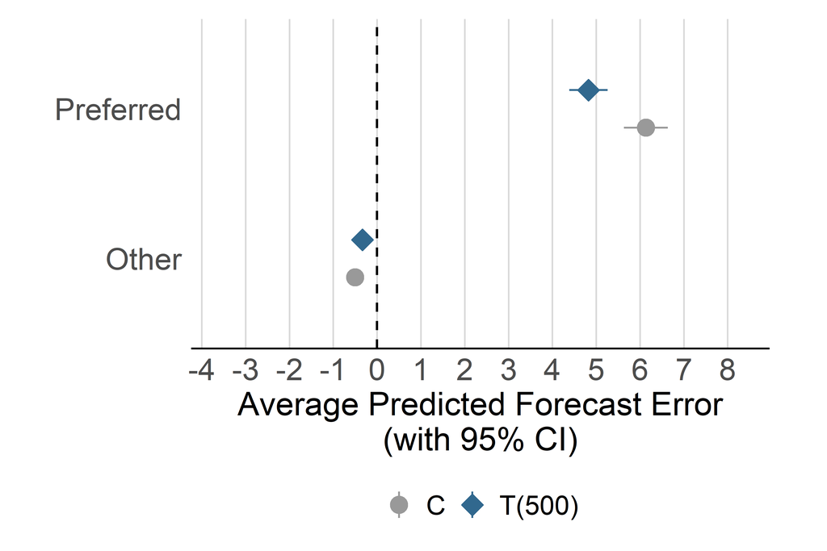

```r
plot_pref_pid_saxony <- plot_wishful_thinking_pred(pid_saxony$pred, "preferred_party_pid_dummy", # helper
  election = "saxony",
  y_limits = c(-4, 8), y_breaks = seq(-4, 8, by = 1)
)
plot_pref_pid_saxony
```

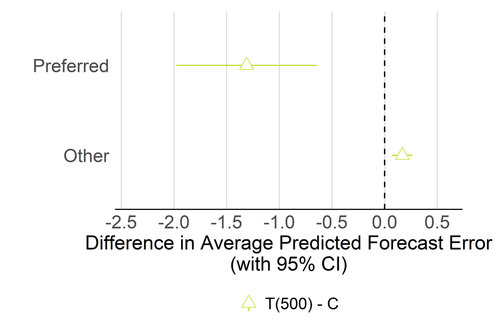

```r
save_figure(plot_pref_pid_saxony, "figure_C5c_h3_pid_saxony",
  election = "saxony", # helper
  width = "subfigure", aspect = 1 / 2
)

plot_pref_pid_fd_saxony <- plot_wishful_thinking_diff(pid_saxony$diff, "preferred_party_pid_dummy", # helper
  election = "saxony",
  y_limits = c(-2.5, 0.5),
  y_breaks = seq(-2.5, 0.5, by = 0.5)
)
plot_pref_pid_fd_saxony
```

```r
save_figure(plot_pref_pid_fd_saxony, "figure_C5d_h3_pid_fd_saxony",
  election = "saxony", # helper
  width = "subfigure", aspect = 1 / 2
)
```

```r
print_values(pid_saxony$diff, c("diff", "preferred_party_pid_dummy", est_cols)) # helper
```

```
       diff preferred_party_pid_dummy estimate conf.low conf.high
 T(500) - C                         0     0.17     0.07      0.26
 T(500) - C                         1    -1.31    -1.98     -0.64
```

## Model 3e: PTV Score (Figure C.6)

Forecast error on treatment interacted with the PTV score (1-11) of each party.

```r
m_pref_ptv_score_saxony <- lm(list_votes_exp_diff ~ treatment * ptv_score + lead_time + party,
  data = data_saxony_ptvscore_main
)
lmtest::coeftest(m_pref_ptv_score_saxony, vcov = sandwich::vcovCL(m_pref_ptv_score_saxony, cluster = ~ResponseId))
```

```
t test of coefficients:

                                   Estimate Std. Error t value Pr(>|t|)
(Intercept)                        -3.55947    0.21801  -16.33  < 2e-16 ***
treatmentTreatment (500)            0.54681    0.11524    4.74  2.1e-06 ***
ptv_score                           0.76173    0.02220   34.31  < 2e-16 ***
lead_time3                         -0.00299    0.20886   -0.01   0.9886
lead_time4                          0.03288    0.22403    0.15   0.8833
lead_time5                          0.04920    0.16577    0.30   0.7666
lead_time6                          0.19483    0.12902    1.51   0.1310
lead_time7                         -0.18668    0.30867   -0.60   0.5453
lead_time8                          0.03167    0.19499    0.16   0.8710
lead_time9                          0.04674    0.13208    0.35   0.7235
lead_time10                        -0.36485    0.28747   -1.27   0.2044
lead_time11                        -0.08905    0.46025   -0.19   0.8466
lead_time12                         0.13673    0.15022    0.91   0.3627
lead_time13                         0.17494    0.13004    1.35   0.1785
lead_time14                         0.21857    0.12502    1.75   0.0804 .
lead_time15                         0.10696    0.13141    0.81   0.4157
lead_time16                         0.11282    0.13403    0.84   0.3999
lead_time17                         0.06332    0.13494    0.47   0.6389
lead_time18                        -0.16589    0.13108   -1.27   0.2057
lead_time19                        -0.04960    0.13916   -0.36   0.7215
lead_time20                         0.06924    0.22751    0.30   0.7609
lead_time21                         0.05421    0.14672    0.37   0.7118
lead_time22                         0.22198    0.13078    1.70   0.0896 .
lead_time23                         0.19075    0.13499    1.41   0.1576
lead_time24                         0.08442    0.14163    0.60   0.5511
lead_time25                        -0.10553    0.13192   -0.80   0.4237
lead_time26                         0.30800    0.14172    2.17   0.0298 *
lead_time27                         0.29524    0.13318    2.22   0.0266 *
lead_time28                         0.19389    0.12924    1.50   0.1335
lead_time29                         0.16573    0.12278    1.35   0.1771
lead_time30                         0.03245    0.14809    0.22   0.8265
lead_time31                         0.34705    0.15907    2.18   0.0291 *
lead_time32                         0.20001    0.14627    1.37   0.1715
lead_time33                         0.43841    0.14076    3.11   0.0018 **
lead_time34                         0.18505    0.13855    1.34   0.1817
lead_time35                         0.11328    0.14592    0.78   0.4376
lead_time36                         0.05853    0.12951    0.45   0.6513
lead_time37                         0.14118    0.12947    1.09   0.2755
partyBSW                           -0.29038    0.18666   -1.56   0.1198
partyCDU                           -4.77444    0.22321  -21.39  < 2e-16 ***
partyFDP                            3.55189    0.17914   19.83  < 2e-16 ***
partyFree Voters                    2.66915    0.17664   15.11  < 2e-16 ***
partyGreens                         1.26680    0.19233    6.59  4.5e-11 ***
partyLeft                           1.67523    0.18895    8.87  < 2e-16 ***
partySPD                            0.98835    0.20339    4.86  1.2e-06 ***
treatmentTreatment (500):ptv_score -0.13376    0.02893   -4.62  3.8e-06 ***
---
Signif. codes:  0 '***' 0.001 '**' 0.01 '*' 0.05 '.' 0.1 ' ' 1
```

```r
count_model_n(m_pref_ptv_score_saxony, data_saxony_ptvscore_main) # helper
```

```
# A tibble: 1 × 2
  respondents observations
        <int>        <int>
1        5554        44274
```

```r
ptv_score_saxony <- compute_treatment_effects(m_pref_ptv_score_saxony, data_saxony_ptvscore_main, # helper
  by = "ptv_score", vcov = ~ResponseId
)
ptv_score_saxony$pred <- ptv_score_saxony$pred %>%
  mutate(treatment = recode_groups_saxony(treatment)) # helper
```

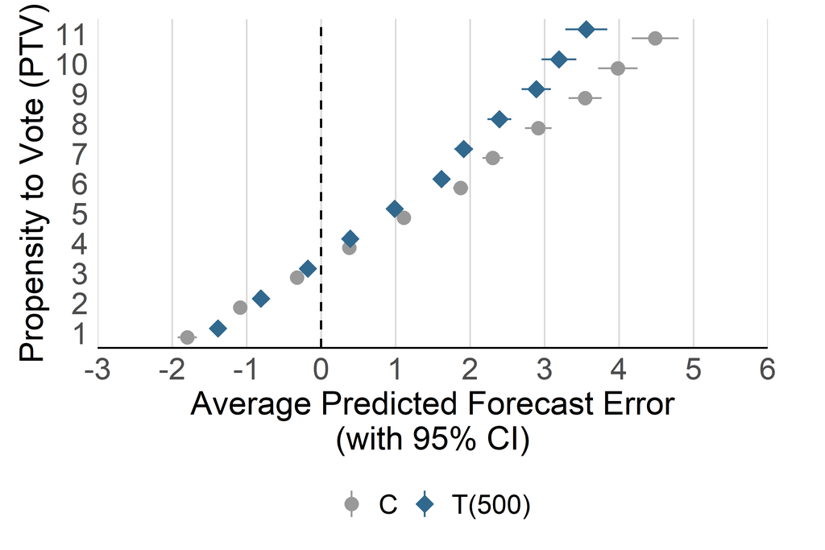

```r
plot_ptv_score_saxony <- plot_ptv_score(ptv_score_saxony$pred, election = "saxony") # helper
plot_ptv_score_saxony
```

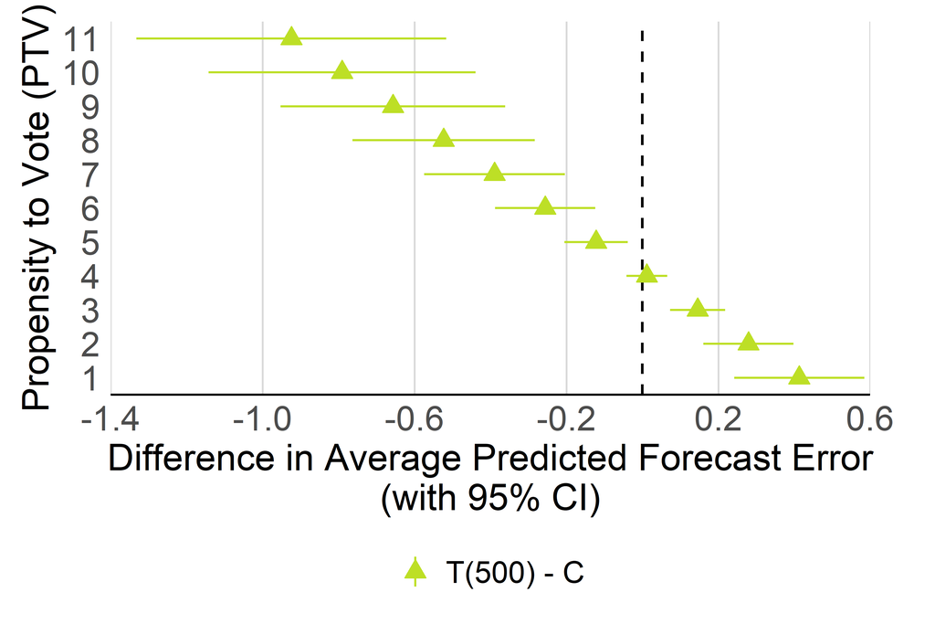

```r
save_figure(plot_ptv_score_saxony, "figure_C6c_h3_ptvscore_saxony",
  election = "saxony", # helper
  width = "subfigure", aspect = 8 / 9
)

plot_ptv_score_fd_saxony <- plot_ptv_score(ptv_score_saxony$diff, election = "saxony", diff = TRUE) # helper
plot_ptv_score_fd_saxony
```

```r
save_figure(plot_ptv_score_fd_saxony, "figure_C6d_h3_ptvscore_fd_saxony",
  election = "saxony", # helper
  width = "subfigure", aspect = 8 / 9
)
```

Values at PTV 1 and 11 (paper section Results, robustness checks).

```r
ptv_score_saxony$pred %>%
  filter(ptv_score %in% c(1, 11)) %>%
  print_values(c("treatment", "ptv_score", est_cols)) # helper
```

```
 treatment ptv_score estimate conf.low conf.high
         C         1    -1.80    -1.93     -1.67
         C        11     4.49     4.17      4.80
    T(500)         1    -1.38    -1.50     -1.27
    T(500)        11     3.56     3.28      3.84
```

```r
ptv_score_saxony$diff %>%
  filter(ptv_score %in% c(1, 11)) %>%
  print_values(c("diff", "ptv_score", est_cols)) # helper
```

```
       diff ptv_score estimate conf.low conf.high
 T(500) - C         1     0.41     0.24      0.58
 T(500) - C        11    -0.92    -1.33     -0.52
```

Lowest PTV score with a positive forecast error, by group.

```r
ptv_score_saxony$pred %>%
  filter(estimate > 0) %>%
  group_by(treatment) %>%
  summarize(first_positive_score = min(ptv_score))
```

```
# A tibble: 2 × 2
  treatment first_positive_score
  <fct>                    <dbl>
1 C                            4
2 T(500)                       4
```

## Heterogeneity by Education (Figure C.11)

Forecast error on treatment interacted with the preferred-party dummy (PTV) and educational attainment.

```r
data_saxony_ptv_educ_main <- data_saxony_ptv_main %>%
  left_join(data_saxony_main %>% select(ResponseId, education_eng), by = "ResponseId") %>%
  filter(!is.na(education_eng), education_eng != "Still in School") %>%
  mutate(education_eng = droplevels(factor(education_eng, levels = c("Low", "Medium", "High"))))

m_pref_ptv_educ_saxony <- lm(
  list_votes_exp_diff ~ treatment * preferred_party_ptv_dummy * education_eng + lead_time + party,
  data = data_saxony_ptv_educ_main
)
count_model_n(m_pref_ptv_educ_saxony, data_saxony_ptv_educ_main) # helper
```

```
# A tibble: 1 × 2
  respondents observations
        <int>        <int>
1        4525        36076
```

```r
ptv_educ_saxony <- compute_treatment_effects(m_pref_ptv_educ_saxony, data_saxony_ptv_educ_main, # helper
  by = c("preferred_party_ptv_dummy", "education_eng"), vcov = ~ResponseId
)
ptv_educ_saxony$pred <- ptv_educ_saxony$pred %>%
  mutate(
    treatment = recode_groups_saxony(treatment), # helper
    preferred_party_ptv_dummy = factor(preferred_party_ptv_dummy, labels = pref_label)
  )
ptv_educ_saxony$diff <- ptv_educ_saxony$diff %>%
  mutate(
    education_eng = factor(education_eng, levels = c("Low", "Medium", "High")),
    preferred_party_ptv_dummy = factor(preferred_party_ptv_dummy, labels = pref_label)
  )
```

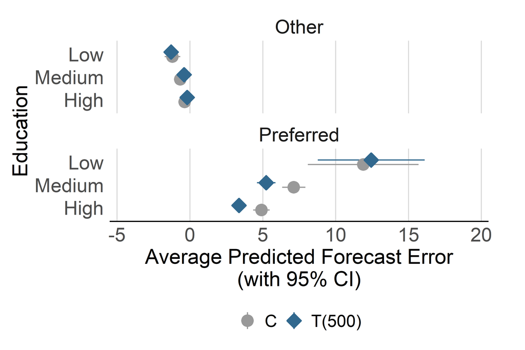

```r
plot_ptv_educ_saxony <- plot_by_moderator( # helper
  ptv_educ_saxony$pred, "education_eng", "Education", "Average Predicted Forecast Error\n(with 95% CI)",
  election = "saxony", facet = TRUE, reverse_x = TRUE
)
plot_ptv_educ_saxony
```

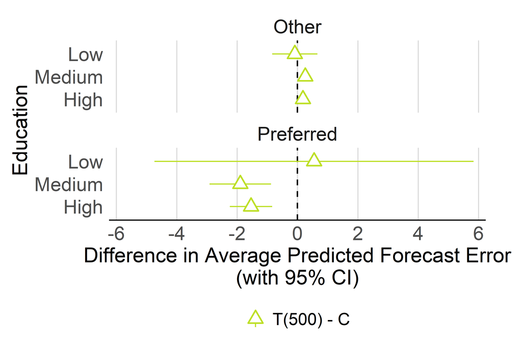

```r
save_figure(plot_ptv_educ_saxony, "figure_C11c_h3_ptv_educ_saxony",
  election = "saxony", # helper
  width = "subfigure", aspect = 6 / 8
)

plot_ptv_educ_fd_saxony <- plot_by_moderator( # helper
  ptv_educ_saxony$diff, "education_eng", "Education", "Difference in Average Predicted Forecast Error\n(with 95% CI)",
  election = "saxony", diff = TRUE, facet = TRUE, reverse_x = TRUE
)
plot_ptv_educ_fd_saxony
```

```r
save_figure(plot_ptv_educ_fd_saxony, "figure_C11d_h3_ptv_educ_fd_saxony",
  election = "saxony", # helper
  width = "subfigure", aspect = 6 / 8
)
```

```r
print_values(ptv_educ_saxony$diff, c("preferred_party_ptv_dummy", "education_eng", "diff", est_cols)) # helper
```

```
 preferred_party_ptv_dummy education_eng       diff estimate conf.low conf.high
                     Other           Low T(500) - C    -0.09    -0.84      0.66
                     Other        Medium T(500) - C     0.26     0.11      0.41
                     Other          High T(500) - C     0.18     0.07      0.29
                 Preferred           Low T(500) - C     0.55    -4.74      5.84
                 Preferred        Medium T(500) - C    -1.89    -2.91     -0.88
                 Preferred          High T(500) - C    -1.54    -2.24     -0.84
```

## Heterogeneity by Political Interest (Figure C.12)

```r
data_saxony_ptv_polint_main <- data_saxony_ptv_main %>%
  left_join(data_saxony_main %>% select(ResponseId, pol_interest), by = "ResponseId") %>%
  filter(!is.na(pol_interest)) %>%
  mutate(pol_interest = recode_pol_interest(pol_interest, pol_interest_levels_saxony)) %>% # helper
  filter(!is.na(pol_interest))

m_pref_ptv_polint_saxony <- lm(
  list_votes_exp_diff ~ treatment * preferred_party_ptv_dummy * pol_interest + lead_time + party,
  data = data_saxony_ptv_polint_main
)
count_model_n(m_pref_ptv_polint_saxony, data_saxony_ptv_polint_main) # helper
```

```
# A tibble: 1 × 2
  respondents observations
        <int>        <int>
1        4662        37163
```

```r
ptv_polint_saxony <- compute_treatment_effects(m_pref_ptv_polint_saxony, data_saxony_ptv_polint_main, # helper
  by = c("preferred_party_ptv_dummy", "pol_interest"), vcov = ~ResponseId
)
ptv_polint_saxony$pred <- ptv_polint_saxony$pred %>%
  mutate(
    treatment = recode_groups_saxony(treatment), # helper
    preferred_party_ptv_dummy = factor(preferred_party_ptv_dummy, labels = pref_label)
  )
ptv_polint_saxony$diff <- ptv_polint_saxony$diff %>%
  mutate(
    pol_interest = factor(pol_interest, levels = levels(data_saxony_ptv_polint_main$pol_interest)),
    preferred_party_ptv_dummy = factor(preferred_party_ptv_dummy, labels = pref_label)
  )
```

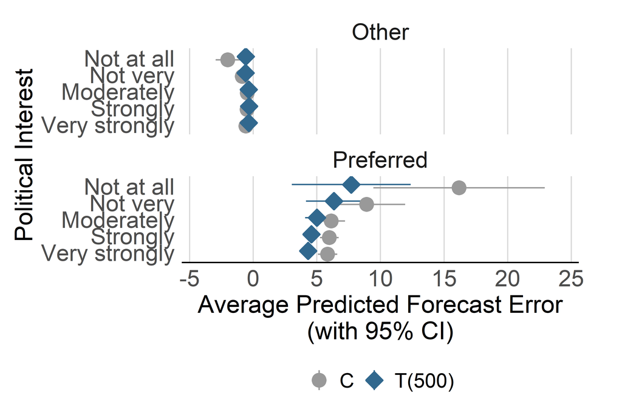

```r
plot_ptv_polint_saxony <- plot_by_moderator( # helper
  ptv_polint_saxony$pred, "pol_interest", "Political Interest", "Average Predicted Forecast Error\n(with 95% CI)",
  election = "saxony", facet = TRUE
)
plot_ptv_polint_saxony
```

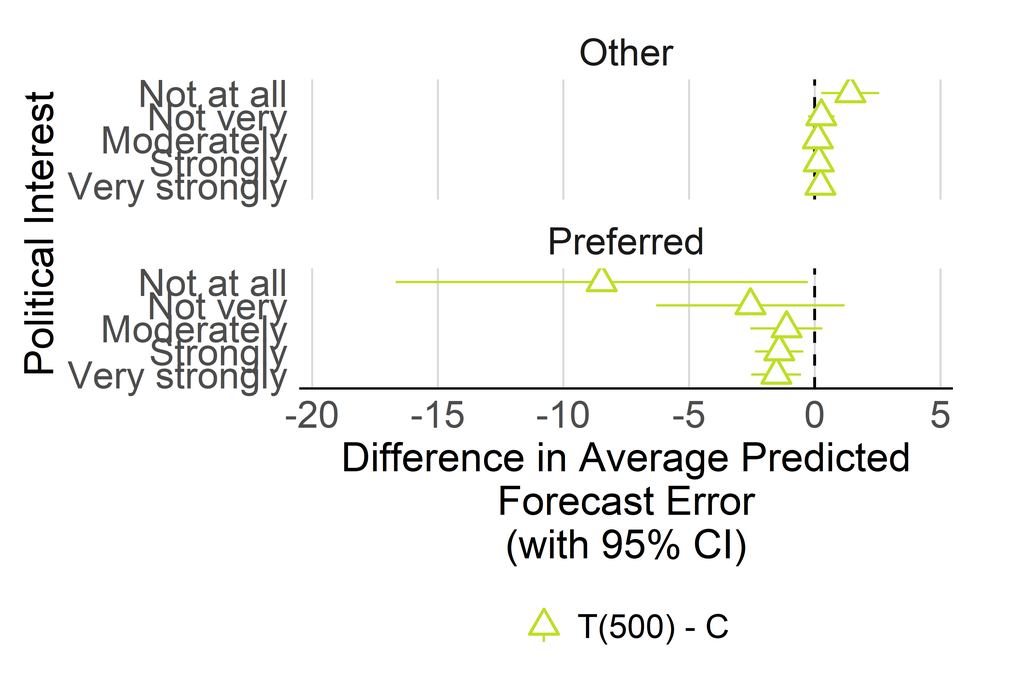

```r
save_figure(plot_ptv_polint_saxony, "figure_C12c_h3_ptv_polint_saxony",
  election = "saxony", # helper
  width = "subfigure", aspect = 8 / 8
)

plot_ptv_polint_fd_saxony <- plot_by_moderator( # helper
  ptv_polint_saxony$diff, "pol_interest", "Political Interest", "Difference in Average Predicted\nForecast Error\n(with 95% CI)",
  election = "saxony", diff = TRUE, facet = TRUE
)
plot_ptv_polint_fd_saxony
```

```r
save_figure(plot_ptv_polint_fd_saxony, "figure_C12d_h3_ptv_polint_fd_saxony",
  election = "saxony", # helper
  width = "subfigure", aspect = 8 / 8
)
```

```r
print_values(ptv_polint_saxony$diff, c("preferred_party_ptv_dummy", "pol_interest", "diff", est_cols)) # helper
```

```
 preferred_party_ptv_dummy  pol_interest       diff estimate conf.low conf.high
                     Other Very strongly T(500) - C     0.22     0.08      0.37
                     Other      Strongly T(500) - C     0.16     0.02      0.30
                     Other    Moderately T(500) - C     0.12    -0.09      0.33
                     Other      Not very T(500) - C     0.26    -0.27      0.79
                     Other    Not at all T(500) - C     1.41     0.26      2.56
                 Preferred Very strongly T(500) - C    -1.53    -2.52     -0.54
                 Preferred      Strongly T(500) - C    -1.42    -2.37     -0.46
                 Preferred    Moderately T(500) - C    -1.13    -2.56      0.31
                 Preferred      Not very T(500) - C    -2.56    -6.31      1.19
                 Preferred    Not at all T(500) - C    -8.47   -16.67     -0.28
```

# Regression Table (Table C.2)

```r
model_list_saxony <- list(
  m_time_full_saxony,
  m_mae_full_saxony,
  m_rmse_full_saxony,
  m_pref_ptv_saxony,
  m_pref_ptv_ties_saxony,
  m_pref_vi_saxony,
  m_pref_pid_saxony,
  m_pref_ptv_score_saxony
)

write_models_table( # helper
  models      = model_list_saxony,
  header      = header_models,
  model_names = labels_models,
  groups      = groups_models,
  coef_map    = coef_map_saxony,
  cluster_idx = 4:8,
  caption     = "Linear Regression Models for Saxony",
  label       = "tab:models_saxony",
  note        = note_models,
  file        = "output/tables/table_C2_models_saxony.tex"
)
```

# Robustness: Without Excluding Satisficers

## Who Was Excluded (Table C.4)

Share excluded by experimental group (paper section Data).

```r
data_saxony_noexcl %>%
  transmute(treatment = as.character(treatment), excluded) %>%
  bind_rows(mutate(., treatment = "All")) %>%
  group_by(treatment) %>%
  summarize(n = n(), n_excluded = sum(excluded), share_excluded = mean(excluded), .groups = "drop") %>%
  print_values(digits = 4) # helper
```

```
       treatment    n n_excluded share_excluded
             All 5659         97         0.0171
         Control 2889         65         0.0225
 Treatment (500) 2770         32         0.0116
```

```r
m_excl_logit_saxony_demo <- glm(
  excluded ~ treatment + age_group + gender_eng2 + education_eng + turnout_int_dummy + recruit,
  family = binomial,
  data = data_saxony_noexcl
)
summary(m_excl_logit_saxony_demo)
```

```
Call:
glm(formula = excluded ~ treatment + age_group + gender_eng2 +
    education_eng + turnout_int_dummy + recruit, family = binomial,
    data = data_saxony_noexcl)

Coefficients:
                             Estimate Std. Error z value Pr(>|z|)
(Intercept)                   -2.2781     0.4394   -5.18  2.2e-07 ***
treatmentTreatment (500)      -0.7050     0.2196   -3.21   0.0013 **
age_group30-39                 0.0692     0.3951    0.18   0.8610
age_group40-49                 0.0860     0.3862    0.22   0.8239
age_group50-59                 0.0784     0.3796    0.21   0.8364
age_group60+                   0.2106     0.3787    0.56   0.5781
gender_eng2Women               0.0956     0.2122    0.45   0.6522
education_engMedium           -0.3678     0.3352   -1.10   0.2726
education_engHigh             -0.9458     0.3669   -2.58   0.0099 **
education_engStill in School -14.2433   460.2937   -0.03   0.9753
turnout_int_dummyja           -0.8269     0.2617   -3.16   0.0016 **
recruitSM                     -0.7050     0.2415   -2.92   0.0035 **
---
Signif. codes:  0 '***' 0.001 '**' 0.01 '*' 0.05 '.' 0.1 ' ' 1

(Dispersion parameter for binomial family taken to be 1)

    Null deviance: 969.56  on 5556  degrees of freedom
Residual deviance: 909.58  on 5545  degrees of freedom
  (102 Beobachtungen als fehlend gelöscht)
AIC: 933.6

Number of Fisher Scoring iterations: 16
```

```r
# Row labels and reference categories from the model
coef_names_excl_saxony <- names(coef(m_excl_logit_saxony_demo))
coef_map_excl_saxony <- coef_names_excl_saxony %>%
  str_replace("^\\(Intercept\\)$", "Intercept") %>%
  str_replace("^treatmentTreatment \\(500\\)$", "T(500)") %>%
  str_replace("^age_group", "Age ") %>%
  str_replace("^gender_eng2", "Gender: ") %>%
  str_replace("^education_eng", "Education: ") %>%
  str_replace("^turnout_int_dummyja$", "Intends to Vote") %>%
  str_replace("^recruitSM$", "Recruited via Social Media") %>%
  as.list() %>%
  set_names(coef_names_excl_saxony)
ref_excl_saxony <- m_excl_logit_saxony_demo$xlevels

note_excl_logit_saxony <- paste0(
  "Note: * p < 0.05, ** p < 0.01, *** p < 0.001. Logistic regression of being excluded ",
  "(allocated 100\\% to one party) on treatment and respondent characteristics. ",
  "Reference categories: Control group, age ", ref_excl_saxony$age_group[1],
  ", gender ", ref_excl_saxony$gender_eng2[1], " (incl. diverse), education ",
  ref_excl_saxony$education_eng[1], ", no turnout intention, recruited via online access panel. ",
  "The large standard error of Still in School results from the absence of excluded respondents in this category."
)

write_logit_table( # helper
  m_excl_logit_saxony_demo,
  coef_map = coef_map_excl_saxony,
  caption  = "Logistic Regression of Being Excluded (Allocated 100\\% to One Party) on Treatment and Respondent Characteristics (Saxony)",
  label    = "tab:excl_logit_saxony",
  note     = note_excl_logit_saxony,
  file     = "output/tables/table_C4_exclusions_logit_saxony.tex"
)
```

## Models Without Exclusions (Table C.6)

All main models re-estimated on all respondents. The response time model still drops latency outliers (mean + 2 SD, computed in this sample).

```r
data_saxony_time_noexcl_nooutliers <- data_saxony_time_noexcl %>%
  filter(t_list_votes_exp_Page_Submit <= compute_time_cutoff(t_list_votes_exp_Page_Submit)) # helper

m_time_full_saxony_noexcl <- lm(t_list_votes_exp_Page_Submit_log ~ treatment + baseline_speed + duration + lead_time,
  data = data_saxony_time_noexcl_nooutliers
)
m_mae_full_saxony_noexcl <- lm(list_votes_exp_mae ~ treatment + lead_time, data = data_saxony_noexcl)
m_rmse_full_saxony_noexcl <- lm(list_votes_exp_rmse ~ treatment + lead_time, data = data_saxony_noexcl)
m_pref_ptv_saxony_noexcl <- lm(list_votes_exp_diff ~ treatment * preferred_party_ptv_dummy + lead_time + party,
  data = data_saxony_ptv_noexcl
)
m_pref_ptv_ties_saxony_noexcl <- lm(list_votes_exp_diff ~ treatment * preferred_party_ptv_dummy_ties + lead_time + party,
  data = data_saxony_ptvties_noexcl
)
m_pref_vi_saxony_noexcl <- lm(list_votes_exp_diff ~ treatment * preferred_party_vi_dummy + lead_time + party,
  data = data_saxony_vi_noexcl
)
m_pref_pid_saxony_noexcl <- lm(list_votes_exp_diff ~ treatment * preferred_party_pid_dummy + lead_time + party,
  data = data_saxony_pid_noexcl
)
m_pref_ptv_score_saxony_noexcl <- lm(list_votes_exp_diff ~ treatment * ptv_score + lead_time + party,
  data = data_saxony_ptvscore_noexcl
)

write_models_table( # helper
  models = list(
    m_time_full_saxony_noexcl, m_mae_full_saxony_noexcl, m_rmse_full_saxony_noexcl,
    m_pref_ptv_saxony_noexcl, m_pref_ptv_ties_saxony_noexcl, m_pref_vi_saxony_noexcl,
    m_pref_pid_saxony_noexcl, m_pref_ptv_score_saxony_noexcl
  ),
  header = header_models,
  model_names = labels_models,
  groups = groups_models,
  coef_map = coef_map_saxony,
  cluster_idx = 4:8,
  caption = "Linear Regression Models for Saxony Without Exclusions",
  label = "tab:models_saxony_noexcl",
  note = "Note: * p < 0.05, ** p < 0.01, *** p < 0.001. Same models as Table~\\ref{tab:models_saxony}, but including those respondents who allocated 100\\% to one party.",
  file = "output/tables/table_C6_models_noexcl_saxony.tex"
)
```

## Main Sample vs. No Exclusions (Figure C.7b)

H1 without exclusions, transformed to seconds as in Figure 2.

```r
set.seed(20240901)
m_time_full_avg_case_sim_saxony_noexcl <- simloglm(m_time_full_saxony_noexcl, scenario = list(
  treatment = c("Control", "Treatment (500)"),
  baseline_speed = mean(data_saxony_time_noexcl_nooutliers$baseline_speed),
  duration = mean(data_saxony_time_noexcl_nooutliers$duration),
  lead_time = "20"
))
time_median_saxony_noexcl <- compute_time_effects(m_time_full_avg_case_sim_saxony_noexcl, "median", time_diffs_saxony) # helper

treatments_saxony <- c("Control", "Treatment (500)")
noexcl_comparison_saxony <- list(
  compute_sample_effects_time(
    m_time_full_avg_case_sim_saxony, treatments_saxony, # helper
    time_median_saxony$diff, "Main", "H1: Response Time (s, median)"
  ),
  compute_sample_effects_time(
    m_time_full_avg_case_sim_saxony_noexcl, treatments_saxony, # helper
    time_median_saxony_noexcl$diff, "No excl.", "H1: Response Time (s, median)"
  ),
  compute_sample_effects(m_mae_full_saxony, data_saxony_main, "Main", "H2: MAE"), # helper
  compute_sample_effects(m_mae_full_saxony_noexcl, data_saxony_noexcl, "No excl.", "H2: MAE"), # helper
  compute_sample_effects(m_pref_ptv_saxony, data_saxony_ptv_main, "Main", "H3: Forecast Error (PTV)", # helper
    by = "preferred_party_ptv_dummy", vcov = ~ResponseId
  ),
  compute_sample_effects(m_pref_ptv_saxony_noexcl, data_saxony_ptv_noexcl, "No excl.", "H3: Forecast Error (PTV)", # helper
    by = "preferred_party_ptv_dummy", vcov = ~ResponseId
  )
)

fd_noexcl_saxony <- map_dfr(noexcl_comparison_saxony, "diff") %>%
  mutate(
    outcome = factor(outcome, levels = sample_outcome_levels)
  )
print_values(fd_noexcl_saxony, c("outcome", "diff", "sample", est_cols)) # helper
```

```
                             outcome       diff   sample estimate conf.low conf.high
       H1: Response Time (s, median) T(500) - C     Main     8.32     5.46     11.88
       H1: Response Time (s, median) T(500) - C No excl.     9.80     6.61     13.78
                             H2: MAE T(500) - C     Main    -0.29    -0.45     -0.13
                             H2: MAE T(500) - C No excl.    -0.41    -0.58     -0.23
     H3: Forecast Error (PTV): Other T(500) - C     Main     0.19     0.10      0.28
 H3: Forecast Error (PTV): Preferred T(500) - C     Main    -1.50    -2.14     -0.86
     H3: Forecast Error (PTV): Other T(500) - C No excl.     0.30     0.19      0.41
 H3: Forecast Error (PTV): Preferred T(500) - C No excl.    -2.21    -2.99     -1.43
```

```r
plot_noexcl_fd_saxony <- plot_sample_diff(fd_noexcl_saxony) # helper
plot_noexcl_fd_saxony
```

[figure not shown]

```r
save_figure(plot_noexcl_fd_saxony, "figure_C7b_h123_noexcl_fd_saxony",
  election = "saxony", # helper
  width = "full", aspect = 8 / 12
)
```

# Robustness: Recruitment Channel

Models (1), (2a) and (3a) estimated separately for respondents recruited through the online access panel (OAP) and through social media (SM), with the same specifications, exclusions and latency outliers as the main models.

## Models by Recruitment Channel (Table C.7)

```r
data_saxony_main %>%
  count(recruit, treatment) %>%
  pivot_wider(names_from = treatment, values_from = n)
```

```
# A tibble: 2 × 3
  recruit Control `Treatment (500)`
  <chr>     <int>             <int>
1 OAP        1062              1099
2 SM         1762              1639
```

```r
ids_oap_saxony <- data_saxony_main %>% filter(recruit == "OAP") %>% pull(ResponseId)
ids_sm_saxony <- data_saxony_main %>% filter(recruit == "SM") %>% pull(ResponseId)

data_saxony_time_oap_main <- filter_ids(data_saxony_time_main_nooutliers, ids_oap_saxony) # helper
data_saxony_time_sm_main <- filter_ids(data_saxony_time_main_nooutliers, ids_sm_saxony) # helper
data_saxony_oap_main <- filter_ids(data_saxony_main, ids_oap_saxony) # helper
data_saxony_sm_main <- filter_ids(data_saxony_main, ids_sm_saxony) # helper
data_saxony_ptv_oap_main <- filter_ids(data_saxony_ptv_main, ids_oap_saxony) # helper
data_saxony_ptv_sm_main <- filter_ids(data_saxony_ptv_main, ids_sm_saxony) # helper

m_time_full_saxony_oap <- lm(t_list_votes_exp_Page_Submit_log ~ treatment + baseline_speed + duration + lead_time,
  data = data_saxony_time_oap_main
)
m_time_full_saxony_sm <- lm(t_list_votes_exp_Page_Submit_log ~ treatment + baseline_speed + duration + lead_time,
  data = data_saxony_time_sm_main
)
m_mae_full_saxony_oap <- lm(list_votes_exp_mae ~ treatment + lead_time, data = data_saxony_oap_main)
m_mae_full_saxony_sm <- lm(list_votes_exp_mae ~ treatment + lead_time, data = data_saxony_sm_main)
m_pref_ptv_saxony_oap <- lm(list_votes_exp_diff ~ treatment * preferred_party_ptv_dummy + lead_time + party,
  data = data_saxony_ptv_oap_main
)
m_pref_ptv_saxony_sm <- lm(list_votes_exp_diff ~ treatment * preferred_party_ptv_dummy + lead_time + party,
  data = data_saxony_ptv_sm_main
)

write_models_table( # helper
  models = list(
    m_time_full_saxony_oap, m_time_full_saxony_sm,
    m_mae_full_saxony_oap, m_mae_full_saxony_sm,
    m_pref_ptv_saxony_oap, m_pref_ptv_saxony_sm
  ),
  header = rep(c("OAP", "SM"), 3),
  model_names = c("(1)", "(1)", "(2a)", "(2a)", "(3a)", "(3a)"),
  groups = c(H1 = 2, H2 = 2, H3 = 2),
  coef_map = coef_map_saxony,
  cluster_idx = 5:6,
  # narrower than the page: 1.4 cm columns, 14.2 cm note
  col_width = "1.4cm",
  note_width = "14.2cm",
  caption = "Linear Regression Models for Saxony by Recruitment Channel",
  label = "tab:models_recruit_saxony",
  note = paste0(
    "Note: * p < 0.05, ** p < 0.01, *** p < 0.001. Models (1), (2a) and (3a) of Table~\\ref{tab:models_saxony}, ",
    "estimated separately for respondents recruited through the online access panel (OAP) and through social media (SM). ",
    "Standard errors of (3a) clustered by respondent."
  ),
  file = "output/tables/table_C7_models_recruit_saxony.tex"
)
```

## Differences Between the Channels (Note of Figure C.8)

Pooled models with treatment interacted with the recruitment channel (reference: OAP). H3 with standard errors clustered by respondent.

```r
data_saxony_ptv_recruit_main <- data_saxony_ptv_main %>%
  left_join(data_saxony_main %>% select(ResponseId, recruit), by = "ResponseId")

m_time_full_saxony_recruit_int <- lm(t_list_votes_exp_Page_Submit_log ~ treatment * recruit + baseline_speed + duration + lead_time,
  data = data_saxony_time_main_nooutliers # already contains recruit
)
m_mae_full_saxony_recruit_int <- lm(list_votes_exp_mae ~ treatment * recruit + lead_time, data = data_saxony_main)
m_pref_ptv_saxony_recruit_int <- lm(list_votes_exp_diff ~ treatment * preferred_party_ptv_dummy * recruit + lead_time + party,
  data = data_saxony_ptv_recruit_main
)

# Interaction terms with the channel
extract_recruit_terms <- function(ct, outcome) {
  as_tibble(unclass(ct), rownames = "term") %>%
    filter(str_detect(term, "^treatment.*:recruitSM$")) %>%
    mutate(outcome = outcome)
}
bind_rows(
  extract_recruit_terms(lmtest::coeftest(m_time_full_saxony_recruit_int), "H1: Response Time (log)"),
  extract_recruit_terms(lmtest::coeftest(m_mae_full_saxony_recruit_int), "H2: MAE"),
  extract_recruit_terms(
    lmtest::coeftest(m_pref_ptv_saxony_recruit_int,
      vcov = sandwich::vcovCL(m_pref_ptv_saxony_recruit_int, cluster = ~ResponseId)
    ),
    "H3: Forecast Error (PTV)"
  )
) %>%
  select(outcome, term, estimate = Estimate, se = `Std. Error`, p = `Pr(>|t|)`) %>%
  print_values(digits = 3) # helper
```

```
                  outcome                                                         term estimate    se     p
  H1: Response Time (log)                           treatmentTreatment (500):recruitSM   -0.043 0.032 0.173
                  H2: MAE                           treatmentTreatment (500):recruitSM    0.353 0.156 0.024
 H3: Forecast Error (PTV)                           treatmentTreatment (500):recruitSM   -0.286 0.111 0.010
 H3: Forecast Error (PTV) treatmentTreatment (500):preferred_party_ptv_dummy:recruitSM    2.126 0.875 0.015
```

## Online Access Panel vs. Social Media (Figure C.8)

H1 per channel, transformed to seconds as in Figure 2. Average case of the channel’s sample, lead time of 20 days.

```r
set.seed(20240901)
m_time_full_avg_case_sim_saxony_oap <- simloglm(m_time_full_saxony_oap, scenario = list(
  treatment = treatments_saxony,
  baseline_speed = mean(data_saxony_time_oap_main$baseline_speed),
  duration = mean(data_saxony_time_oap_main$duration),
  lead_time = "20"
))
set.seed(20240901)
m_time_full_avg_case_sim_saxony_sm <- simloglm(m_time_full_saxony_sm, scenario = list(
  treatment = treatments_saxony,
  baseline_speed = mean(data_saxony_time_sm_main$baseline_speed),
  duration = mean(data_saxony_time_sm_main$duration),
  lead_time = "20"
))
time_median_saxony_oap <- compute_time_effects(m_time_full_avg_case_sim_saxony_oap, "median", time_diffs_saxony) # helper
time_median_saxony_sm <- compute_time_effects(m_time_full_avg_case_sim_saxony_sm, "median", time_diffs_saxony) # helper

recruit_comparison_saxony <- list(
  compute_sample_effects_time(
    m_time_full_avg_case_sim_saxony_oap, treatments_saxony, # helper
    time_median_saxony_oap$diff, "OAP", "H1: Response Time (s, median)"
  ),
  compute_sample_effects_time(
    m_time_full_avg_case_sim_saxony_sm, treatments_saxony, # helper
    time_median_saxony_sm$diff, "SM", "H1: Response Time (s, median)"
  ),
  compute_sample_effects(m_mae_full_saxony_oap, data_saxony_oap_main, "OAP", "H2: MAE"), # helper
  compute_sample_effects(m_mae_full_saxony_sm, data_saxony_sm_main, "SM", "H2: MAE"), # helper
  compute_sample_effects(m_pref_ptv_saxony_oap, data_saxony_ptv_oap_main, "OAP", "H3: Forecast Error (PTV)", # helper
    by = "preferred_party_ptv_dummy", vcov = ~ResponseId
  ),
  compute_sample_effects(m_pref_ptv_saxony_sm, data_saxony_ptv_sm_main, "SM", "H3: Forecast Error (PTV)", # helper
    by = "preferred_party_ptv_dummy", vcov = ~ResponseId
  )
)

fd_recruit_saxony <- map_dfr(recruit_comparison_saxony, "diff") %>%
  mutate(
    outcome = factor(outcome, levels = sample_outcome_levels),
    sample = factor(sample, levels = c("OAP", "SM"))
  )

plot_recruit_fd_saxony <- plot_sample_diff(fd_recruit_saxony,
  colors = recruit_colors, # helper
  shapes = recruit_shapes, fills = recruit_fills
)
plot_recruit_fd_saxony
```

[figure not shown]

```r
save_figure(plot_recruit_fd_saxony, "figure_C8_h123_recruit_fd_saxony",
  election = "saxony", # helper
  width = "full", aspect = 8 / 12
)
```

Conditional medians and differences per channel (note of Figure C.8).

```r
map_dfr(recruit_comparison_saxony[1:2], "pred") %>%
  print_values(c("sample", "treatment", est_cols), digits = 1) # helper
```

```
 sample       treatment estimate conf.low conf.high
    OAP         Control     41.7     24.5      68.6
    OAP Treatment (500)     47.3     28.3      77.9
     SM         Control    107.4     83.8     135.5
     SM Treatment (500)    117.8     92.3     149.1
```

```r
print_values(fd_recruit_saxony, c("outcome", "diff", "sample", est_cols)) # helper
```

```
                             outcome       diff sample estimate conf.low conf.high
       H1: Response Time (s, median) T(500) - C    OAP     5.66     2.59     11.05
       H1: Response Time (s, median) T(500) - C     SM    10.38     6.18     15.30
                             H2: MAE T(500) - C    OAP    -0.52    -0.82     -0.23
                             H2: MAE T(500) - C     SM    -0.19    -0.35     -0.04
     H3: Forecast Error (PTV): Other T(500) - C    OAP     0.39     0.19      0.59
 H3: Forecast Error (PTV): Preferred T(500) - C    OAP    -2.84    -4.23     -1.44
     H3: Forecast Error (PTV): Other T(500) - C     SM     0.11     0.02      0.20
 H3: Forecast Error (PTV): Preferred T(500) - C     SM    -0.99    -1.58     -0.40
```